# Practica 2

Carmen Liberal, Marcos López, Lara Montero

2025-05-19

# 1. Planteamiento del Problema

Este conjunto de datos contienen la información para dar una estimación de los niveles de obesidad de personas residentes en Mexico, Perú y Colombia.

En este dataset podemos encontrar distintos tipos de variables:

Dado nuestro problema, que es averiguar el nivel de obesidad de las personas según ciertas variables, buscamos crear un modelo de aprendizaje supervisado para poder averiguar de la forma más precisa el nivel de obesidad que tiene o que puede desarrollar una persona.

# 2. Entrenamiento de modelos y programación

## Modelos

### k-NN

En esta sección se analiza el algoritmo de clasificación k-Nearest Neighbors (k-NN), con el objetivo de predecir el nivel de obesidad que puede alcanzar una persona, utilizando variables personales como edad, altura o peso, así como información sobre sus hábitos alimentarios, de actividad física y estilo de vida.

El algoritmo k-NN se basa en la idea de que una observación será similar a aquellas que tiene más cerca en el espacio de características. Es un modelo no paramétrico, lo que significa que no hace suposiciones sobre la distribución de los datos, y es especialmente útil cuando se desea aplicar una lógica de clasificación intuitiva basada en similitud.

En el contexto de este problema de clasificación multiclase —donde la variable objetivo NObeyesdad puede tomar siete valores distintos— k-NN es una opción válida, ya que maneja bien múltiples clases sin necesidad de modificar su estructura interna.

Antes de entrenar el modelo, se ha llevado a cabo un preprocesamiento imprescindible: se han codificado las variables categóricas mediante técnicas como one-hot encoding o codificación ordinal, y se han escalado todas las variables numéricas para que ninguna tenga un peso desproporcionado al calcular las distancias. Estas transformaciones son esenciales, ya que k-NN se basa en una métrica de distancia (normalmente euclídea) que es sensible a la escala de los datos.

```r
# Transformamos nuestra variable objetivo en factor.
train$NObeyesdad <- as.factor(train$NObeyesdad)
test$NObeyesdad <- as.factor(test$NObeyesdad)

# Creamos una funcón para normalizar las variables.
normalize <- function(x) {
  return ((x - min(x)) / (max(x) - min(x)))
}

# Seleccionamos las variables que vamos a necesitar para el modelo.
train.df <- dplyr::select(train, Gender, Height, Weight, family_history_with_overweight, FAVC, FAF, MTRANS, NObeyesdad)
test.df <- dplyr::select(test, Gender, Height, Weight, family_history_with_overweight, FAVC, FAF, MTRANS, NObeyesdad)
val.df <- dplyr::select(val, Gender, Height, Weight, family_history_with_overweight, FAVC, FAF, MTRANS, NObeyesdad)

# Primero de todo, vamos a crear una receta para asegurarnos de que train, test y val sean consistentes, para poder tener las mismas variables en todas y que no halla problemas.
receta <- recipe(NObeyesdad ~ ., data = train.df) %>%
  step_dummy(all_nominal(), -all_outcomes()) %>%
  step_scale(all_numeric()) %>%
  step_zv(all_predictors()) %>%
  step_nzv(all_predictors())

# One-Hot Encoding con train, test y validation
train_prep <- prep(receta, training = train.df)
train.df <- bake(train_prep, new_data = train.df)
test.df <- bake(train_prep, new_data = test.df)
val.df <- bake(train_prep, new_data = val.df)
```

Antes de hacer cualquier modelo, vamos a observar como se ven los datos, depues de la transformación que hemos hecho, vamos a comprobar que todo está bien y que no hay que ajustar nada. Para hacer esto, vamos a ver el resumen de train.df y test.df.

```r
summary(train.df)
```

```
##      Height          Weight           FAF                       NObeyesdad
##  Min.   :15.80   Min.   :1.492   Min.   :0.0000   Insufficient_Weight:161
##  1st Qu.:17.38   1st Qu.:2.487   1st Qu.:0.1172   Normal_Weight      :196
##  Median :18.13   Median :3.150   Median :1.1606   Obesity_Type_I     :199
##  Mean   :18.15   Mean   :3.288   Mean   :1.1642   Obesity_Type_II    :177
##  3rd Qu.:18.88   3rd Qu.:4.076   3rd Qu.:1.8884   Obesity_Type_III   :188
##  Max.   :21.07   Max.   :6.316   Max.   :3.4819   Overweight_Level_I :172
##                                                   Overweight_Level_II:173
##   Gender_Male    family_history_with_overweight_yes    FAVC_yes
##  Min.   :0.000   Min.   :0.000                      Min.   :0.000
##  1st Qu.:0.000   1st Qu.:2.584                      1st Qu.:3.041
##  Median :1.999   Median :2.584                      Median :3.041
##  Mean   :1.008   Mean   :2.110                      Mean   :2.666
##  3rd Qu.:1.999   3rd Qu.:2.584                      3rd Qu.:3.041
##  Max.   :1.999   Max.   :2.584                      Max.   :3.041
##
##  MTRANS_Public_Transportation
##  Min.   :0.000
##  1st Qu.:0.000
##  Median :2.286
##  Mean   :1.697
##  3rd Qu.:2.286
##  Max.   :2.286
##
```

```r
summary(test.df)
```

```
##      Height          Weight           FAF                       NObeyesdad
##  Min.   :15.82   Min.   :1.531   Min.   :0.0000   Insufficient_Weight:62
##  1st Qu.:17.38   1st Qu.:2.635   1st Qu.:0.1798   Normal_Weight      :44
##  Median :18.13   Median :3.178   Median :1.1534   Obesity_Type_I     :85
##  Mean   :18.11   Mean   :3.317   Mean   :1.1381   Obesity_Type_II    :55
##  3rd Qu.:18.76   3rd Qu.:4.115   3rd Qu.:1.9291   Obesity_Type_III   :68
##  Max.   :21.11   Max.   :6.147   Max.   :3.4819   Overweight_Level_I :58
##                                                   Overweight_Level_II:50
##   Gender_Male    family_history_with_overweight_yes    FAVC_yes
##  Min.   :0.000   Min.   :0.000                      Min.   :0.000
##  1st Qu.:0.000   1st Qu.:2.584                      1st Qu.:3.041
##  Median :1.999   Median :2.584                      Median :3.041
##  Mean   :1.033   Mean   :2.149                      Mean   :2.681
##  3rd Qu.:1.999   3rd Qu.:2.584                      3rd Qu.:3.041
##  Max.   :1.999   Max.   :2.584                      Max.   :3.041
##
##  MTRANS_Public_Transportation
##  Min.   :0.000
##  1st Qu.:2.286
##  Median :2.286
##  Mean   :1.739
##  3rd Qu.:2.286
##  Max.   :2.286
##
```

```r
# Usamos 10-fold cross validation repetida 3 veces
trainControl <- trainControl(method = "repeatedcv",
                             number = 10,
                             repeats = 3,
                             classProbs = TRUE,
                             summaryFunction = multiClassSummary,
                             savePredictions = "final")

set.seed(1)

# Introducimos el frid para buscar el mejor valor para k
grid <- expand.grid(.k = seq(1, 30, by=2))

fit.knn <- train(NObeyesdad ~ .,
                 data = train.df,
                 method = "knn",
                 metric="Accuracy",
                 tuneGrid = grid,
                 trControl=trainControl)

knn.k2 <- fit.knn$bestTune
print(fit.knn)
```

```
## k-Nearest Neighbors
##
## 1266 samples
##    7 predictor
##    7 classes: 'Insufficient_Weight', 'Normal_Weight', 'Obesity_Type_I', 'Obesity_Type_II', 'Obesity_Type_III', 'Overweight_Level_I', 'Overweight_Level_II'
##
## No pre-processing
## Resampling: Cross-Validated (10 fold, repeated 3 times)
## Summary of sample sizes: 1138, 1140, 1140, 1137, 1139, 1140, ...
## Resampling results across tuning parameters:
##
##   k   logLoss    AUC        prAUC       Accuracy   Kappa      Mean_F1
##    1  4.5677205  0.9227851  0.06189551  0.8677509  0.8455905  0.8670430
##    3  2.8796066  0.9452416  0.22632521  0.8364684  0.8090408  0.8345795
##    5  2.2201691  0.9496970  0.32909519  0.8112070  0.7796060  0.8093453
##    7  1.6803489  0.9529278  0.40092874  0.7966982  0.7626955  0.7937635
##    9  1.4139627  0.9524028  0.44335651  0.7763989  0.7390417  0.7720121
##   11  1.3060168  0.9494348  0.47517071  0.7606020  0.7206799  0.7543186
##   13  1.2677547  0.9460944  0.48575810  0.7532148  0.7121377  0.7469529
##   15  1.2244805  0.9428771  0.48929646  0.7398153  0.6964929  0.7324333
##   17  1.1580228  0.9401782  0.49159200  0.7248327  0.6790522  0.7158196
##   19  1.1207975  0.9365991  0.48623258  0.7069384  0.6582361  0.6958474
##   21  1.0396170  0.9339584  0.48211528  0.6927186  0.6416723  0.6811989
##   23  0.9788565  0.9316791  0.47975384  0.6824643  0.6296892  0.6703158
##   25  0.9344800  0.9291340  0.47277347  0.6721568  0.6177030  0.6591478
##   27  0.9347757  0.9267103  0.47429046  0.6595284  0.6029902  0.6452294
##   29  0.9431932  0.9242204  0.47241474  0.6569251  0.5999170  0.6411140
##   Mean_Sensitivity  Mean_Specificity  Mean_Pos_Pred_Value  Mean_Neg_Pred_Value
##   0.8676125         0.9779578         0.8713559            0.9780752
##   0.8360929         0.9727263         0.8396576            0.9729387
##   0.8115380         0.9685364         0.8145653            0.9687592
##   0.7974010         0.9661234         0.8001013            0.9664571
##   0.7773644         0.9627531         0.7797861            0.9632173
##   0.7620560         0.9601508         0.7617879            0.9607207
##   0.7552279         0.9589451         0.7549759            0.9595274
##   0.7417865         0.9567018         0.7394530            0.9573581
##   0.7269870         0.9542170         0.7244298            0.9550127
##   0.7094355         0.9512464         0.7024628            0.9521686
##   0.6954839         0.9488782         0.6885179            0.9498431
##   0.6849582         0.9471638         0.6790658            0.9481692
##   0.6750212         0.9454467         0.6677937            0.9465360
##   0.6625760         0.9433375         0.6551067            0.9445132
##   0.6596587         0.9428939         0.6486020            0.9441234
##   Mean_Precision  Mean_Recall  Mean_Detection_Rate  Mean_Balanced_Accuracy
##   0.8713559       0.8676125    0.12396442           0.9227851
##   0.8396576       0.8360929    0.11949549           0.9044096
##   0.8145653       0.8115380    0.11588671           0.8900372
##   0.8001013       0.7974010    0.11381404           0.8817622
##   0.7797861       0.7773644    0.11091412           0.8700587
##   0.7617879       0.7620560    0.10865743           0.8611034
##   0.7549759       0.7552279    0.10760211           0.8570865
##   0.7394530       0.7417865    0.10568790           0.8492442
##   0.7244298       0.7269870    0.10354753           0.8406020
##   0.7024628       0.7094355    0.10099120           0.8303410
##   0.6885179       0.6954839    0.09895979           0.8221811
##   0.6790658       0.6849582    0.09749490           0.8160610
##   0.6677937       0.6750212    0.09602241           0.8102339
##   0.6551067       0.6625760    0.09421835           0.8029567
##   0.6486020       0.6596587    0.09384645           0.8012763
##
## Accuracy was used to select the optimal model using the largest value.
## The final value used for the model was k = 1.
```

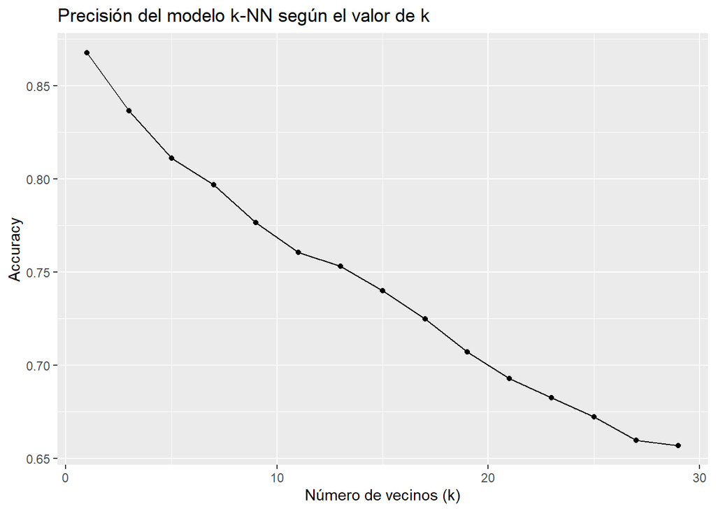

```r
ggplot(fit.knn) +
  labs(title = "Precisión del modelo k-NN según el valor de k",
       x = "Número de vecinos (k)", y = "Accuracy")
```

Como podemos ver tanto en la gráfica como en el modelo, el mejor k posible es 1, sin embargo este valor de k es bastante bajo lo que nos puede indicar que tenemos cierto sobreajuste en nuestros datos, para poder verificar esto, vamos a ver como nos predice el modelo para los datos de entrenamiento y para los datos de test.

```r
prediction_train <- predict(fit.knn,newdata=train.df)
cf <- confusionMatrix(prediction_train, as.factor(train.df$NObeyesdad),positive="yes")
print(cf)
```

```
## Confusion Matrix and Statistics
##
##                      Reference
## Prediction            Insufficient_Weight Normal_Weight Obesity_Type_I
##   Insufficient_Weight                 161             0              0
##   Normal_Weight                         0           196              0
##   Obesity_Type_I                        0             0            199
##   Obesity_Type_II                       0             0              0
##   Obesity_Type_III                      0             0              0
##   Overweight_Level_I                    0             0              0
##   Overweight_Level_II                   0             0              0
##                      Reference
## Prediction            Obesity_Type_II Obesity_Type_III Overweight_Level_I
##   Insufficient_Weight               0                0                  0
##   Normal_Weight                     0                0                  0
##   Obesity_Type_I                    0                0                  0
##   Obesity_Type_II                 177                0                  0
##   Obesity_Type_III                  0              188                  0
##   Overweight_Level_I                0                0                172
##   Overweight_Level_II               0                0                  0
##                      Reference
## Prediction            Overweight_Level_II
##   Insufficient_Weight                   0
##   Normal_Weight                         0
##   Obesity_Type_I                        0
##   Obesity_Type_II                       0
##   Obesity_Type_III                      0
##   Overweight_Level_I                    0
##   Overweight_Level_II                 173
##
## Overall Statistics
##
##                Accuracy : 1
##                  95% CI : (0.9971, 1)
##     No Information Rate : 0.1572
##     P-Value [Acc > NIR] : < 2.2e-16
##
##                   Kappa : 1
##
##  Mcnemar's Test P-Value : NA
```

[output cut: 24 more lines]

```
## Pos Pred Value                        1.0000                    1.0000
## Neg Pred Value                        1.0000                    1.0000
## Prevalence                            0.1485                    0.1359
## Detection Rate                        0.1485                    0.1359
## Detection Prevalence                  0.1485                    0.1359
## Balanced Accuracy                     1.0000                    1.0000
##                      Class: Overweight_Level_II
## Sensitivity                              1.0000
## Specificity                              1.0000
## Pos Pred Value                           1.0000
## Neg Pred Value                           1.0000
## Prevalence                               0.1367
## Detection Rate                           0.1367
## Detection Prevalence                     0.1367
## Balanced Accuracy                        1.0000
```

```r
prediction_test <- predict(fit.knn,newdata=test.df)
conf_matrix <- confusionMatrix(prediction_test, test.df$NObeyesdad)
print(conf_matrix$byClass[, c("F1", "Recall", "Precision")])  # Por clase
```

```
##                                   F1    Recall Precision
## Class: Insufficient_Weight 0.9243697 0.8870968 0.9649123
## Class: Normal_Weight       0.6896552 0.6818182 0.6976744
## Class: Obesity_Type_I      0.9000000 0.8470588 0.9600000
## Class: Obesity_Type_II     0.9557522 0.9818182 0.9310345
## Class: Obesity_Type_III    1.0000000 1.0000000 1.0000000
## Class: Overweight_Level_I  0.7967480 0.8448276 0.7538462
## Class: Overweight_Level_II 0.7547170 0.8000000 0.7142857
```

```r
cat("F1-Macro:", mean(conf_matrix$byClass[, "F1"]), "\n")  # Global
```

```
## F1-Macro: 0.8601774
```

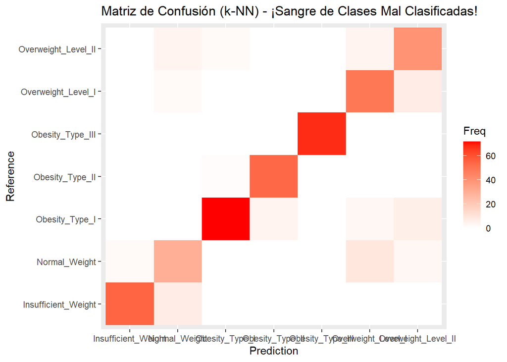

```r
ggplot(as.data.frame(conf_matrix$table), aes(Prediction, Reference, fill = Freq)) +
  geom_tile() +
  scale_fill_gradient(low = "white", high = "red") +
  labs(title = "Matriz de Confusión (k-NN) - ¡Sangre de Clases Mal Clasificadas!")
```

Viendo esta matriz de confusión y bajo la hipótesis que hemos dicho antes, podemos ver como el modelo ajusta bien para los datos con los que hemos entrenado el modelo, esto no es bueno, ya que para datos nuevo no predice bien, ya que el modelo se ajusta también al ruido de nuestros datos de entrenamiento. Como observamos, despues de probar el modelo con datos nuevos, hay bastante diferencia entre el accuracy de la prediccion con los datos de entrenamiento y los datos de testeo, por lo que podemos ver que al elegir el mejor k con grid search, nos lleva al sobreajuste, por lo que ahora vamos a hacer el modelo pero cambiando la métrica a F1. Para evitar esto, vamos a obligar a nuestro modelo a que no seleccione el valor de k = 1.

```r
set.seed(1)

# Introducimos el frid para buscar el mejor valor para k
grid <- expand.grid(.k = seq(5, 30, by=2))

fit.knn <- train(NObeyesdad ~ .,
                 data = train.df,
                 method = "knn",
                 metric="Mean_F1",
                 tuneGrid = grid,
                 trControl=trainControl)

knn.k2 <- fit.knn$bestTune
print(fit.knn)
```

```
## k-Nearest Neighbors
##
## 1266 samples
##    7 predictor
##    7 classes: 'Insufficient_Weight', 'Normal_Weight', 'Obesity_Type_I', 'Obesity_Type_II', 'Obesity_Type_III', 'Overweight_Level_I', 'Overweight_Level_II'
##
## No pre-processing
## Resampling: Cross-Validated (10 fold, repeated 3 times)
## Summary of sample sizes: 1138, 1140, 1140, 1137, 1139, 1140, ...
## Resampling results across tuning parameters:
##
##   k   logLoss    AUC        prAUC      Accuracy   Kappa      Mean_F1
##    5  2.2201691  0.9496970  0.3290952  0.8109445  0.7793074  0.8087768
##    7  1.6803489  0.9529278  0.4009287  0.7962000  0.7620931  0.7933587
##    9  1.4139627  0.9524028  0.4433565  0.7743132  0.7366268  0.7691902
##   11  1.3060168  0.9494348  0.4751707  0.7655911  0.7264833  0.7600814
##   13  1.2677547  0.9460944  0.4857581  0.7542875  0.7133717  0.7482596
##   15  1.2244805  0.9428771  0.4892965  0.7390254  0.6955545  0.7316847
##   17  1.1580228  0.9401782  0.4915920  0.7237784  0.6778358  0.7145885
##   19  1.1207975  0.9365991  0.4862326  0.7056301  0.6567056  0.6946524
##   21  1.0396170  0.9339584  0.4821153  0.6929680  0.6419690  0.6813707
##   23  0.9788565  0.9316791  0.4797538  0.6808899  0.6278647  0.6681631
##   25  0.9344800  0.9291340  0.4727735  0.6729526  0.6186022  0.6593496
##   27  0.9347757  0.9267103  0.4742905  0.6613742  0.6051339  0.6476466
##   29  0.9431932  0.9242204  0.4724147  0.6553271  0.5980585  0.6394190
##   Mean_Sensitivity  Mean_Specificity  Mean_Pos_Pred_Value  Mean_Neg_Pred_Value
##   0.8113914         0.9684953         0.8140872            0.9687381
##   0.7967636         0.9660312         0.8000660            0.9663774
##   0.7754525         0.9624150         0.7765469            0.9629296
##   0.7669280         0.9609760         0.7673067            0.9615039
##   0.7562433         0.9591153         0.7545928            0.9596516
##   0.7408464         0.9565679         0.7384793            0.9572188
##   0.7259066         0.9540506         0.7217651            0.9548159
##   0.7079880         0.9510303         0.7016860            0.9519398
##   0.6957248         0.9489234         0.6883091            0.9498776
##   0.6833726         0.9469037         0.6765312            0.9479366
##   0.6754953         0.9455760         0.6675490            0.9466835
##   0.6642769         0.9436479         0.6574221            0.9447816
##   0.6582304         0.9426272         0.6463992            0.9438698
##   Mean_Precision  Mean_Recall  Mean_Detection_Rate  Mean_Balanced_Accuracy
##   0.8140872       0.8113914    0.11584922           0.8899434
##   0.8000660       0.7967636    0.11374285           0.8813974
##   0.7765469       0.7754525    0.11061617           0.8689338
##   0.7673067       0.7669280    0.10937016           0.8639520
##   0.7545928       0.7562433    0.10775535           0.8576793
##   0.7384793       0.7408464    0.10557506           0.8487072
##   0.7217651       0.7259066    0.10339692           0.8399786
##   0.7016860       0.7079880    0.10080430           0.8295091
##   0.6883091       0.6957248    0.09899542           0.8223241
##   0.6765312       0.6833726    0.09726998           0.8151382
##   0.6675490       0.6754953    0.09613609           0.8105356
##   0.6574221       0.6642769    0.09448202           0.8039624
##   0.6463992       0.6582304    0.09361816           0.8004288
##
## Mean_F1 was used to select the optimal model using the largest value.
## The final value used for the model was k = 5.
```

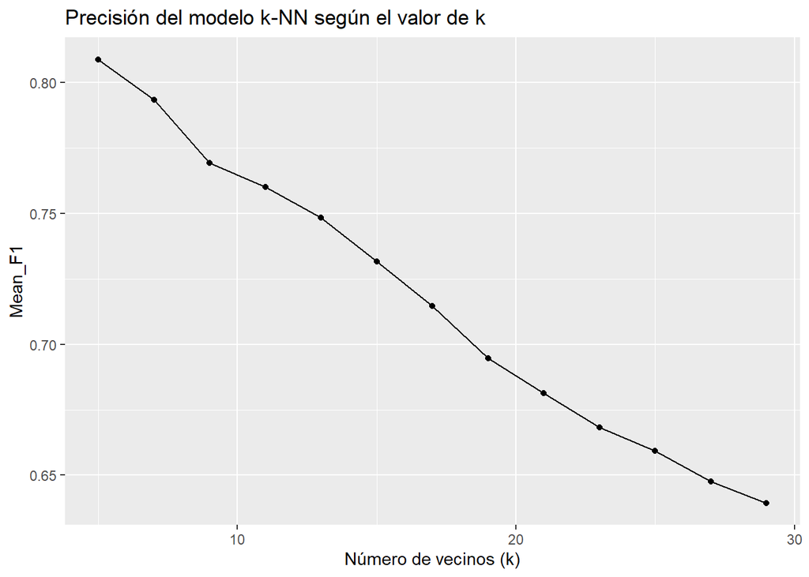

```r
ggplot(fit.knn) +
  labs(title = "Precisión del modelo k-NN según el valor de k",
       x = "Número de vecinos (k)", y = "Mean_F1")
```

Despues de ajustarlo para que el valor mínimo sea k = 5, vemos que nos sale el valor de k = 5, ahora lo que vamos a hacer es comprobar que no hay sobreajuste en nuestros datos.

```r
prediction_train <- predict(fit.knn,newdata=train.df)
cf <- confusionMatrix(prediction_train, as.factor(train.df$NObeyesdad),positive="yes")
print(cf)
```

```
## Confusion Matrix and Statistics
##
##                      Reference
## Prediction            Insufficient_Weight Normal_Weight Obesity_Type_I
##   Insufficient_Weight                 145            15              0
##   Normal_Weight                        15           153              3
##   Obesity_Type_I                        0             0            182
##   Obesity_Type_II                       0             0              2
##   Obesity_Type_III                      0             0              0
##   Overweight_Level_I                    0            18              2
##   Overweight_Level_II                   1            10             10
##                      Reference
## Prediction            Obesity_Type_II Obesity_Type_III Overweight_Level_I
##   Insufficient_Weight               0                0                  1
##   Normal_Weight                     1                0                 22
##   Obesity_Type_I                    3                0                  4
##   Obesity_Type_II                 172                0                  0
##   Obesity_Type_III                  0              188                  0
##   Overweight_Level_I                0                0                122
##   Overweight_Level_II               1                0                 23
##                      Reference
## Prediction            Overweight_Level_II
##   Insufficient_Weight                   0
##   Normal_Weight                         7
##   Obesity_Type_I                        9
##   Obesity_Type_II                       0
##   Obesity_Type_III                      0
##   Overweight_Level_I                    8
##   Overweight_Level_II                 149
##
## Overall Statistics
##
##                Accuracy : 0.8776
##                  95% CI : (0.8582, 0.8951)
##     No Information Rate : 0.1572
##     P-Value [Acc > NIR] : < 2.2e-16
##
##                   Kappa : 0.857
##
##  Mcnemar's Test P-Value : NA
```

[output cut: 24 more lines]

```
## Pos Pred Value                        1.0000                   0.81333
## Neg Pred Value                        1.0000                   0.95520
## Prevalence                            0.1485                   0.13586
## Detection Rate                        0.1485                   0.09637
## Detection Prevalence                  0.1485                   0.11848
## Balanced Accuracy                     1.0000                   0.84185
##                      Class: Overweight_Level_II
## Sensitivity                              0.8613
## Specificity                              0.9588
## Pos Pred Value                           0.7680
## Neg Pred Value                           0.9776
## Prevalence                               0.1367
## Detection Rate                           0.1177
## Detection Prevalence                     0.1532
## Balanced Accuracy                        0.9101
```

```r
prediction_test <- predict(fit.knn,newdata=test.df)
cf <- confusionMatrix(prediction_test, as.factor(test.df$NObeyesdad),positive="yes")
print(cf)
```

```
## Confusion Matrix and Statistics
##
##                      Reference
## Prediction            Insufficient_Weight Normal_Weight Obesity_Type_I
##   Insufficient_Weight                  54             2              0
##   Normal_Weight                         7            29              1
##   Obesity_Type_I                        1             0             75
##   Obesity_Type_II                       0             0              6
##   Obesity_Type_III                      0             0              0
##   Overweight_Level_I                    0             9              2
##   Overweight_Level_II                   0             4              1
##                      Reference
## Prediction            Obesity_Type_II Obesity_Type_III Overweight_Level_I
##   Insufficient_Weight               0                0                  0
##   Normal_Weight                     0                0                  4
##   Obesity_Type_I                    6                0                  0
##   Obesity_Type_II                  49                0                  0
##   Obesity_Type_III                  0               68                  0
##   Overweight_Level_I                0                0                 43
##   Overweight_Level_II               0                0                 11
##                      Reference
## Prediction            Overweight_Level_II
##   Insufficient_Weight                   0
##   Normal_Weight                         4
##   Obesity_Type_I                        7
##   Obesity_Type_II                       0
##   Obesity_Type_III                      0
##   Overweight_Level_I                    5
##   Overweight_Level_II                  34
##
## Overall Statistics
##
##                Accuracy : 0.8341
##                  95% CI : (0.7951, 0.8683)
##     No Information Rate : 0.2014
##     P-Value [Acc > NIR] : < 2.2e-16
##
##                   Kappa : 0.805
##
##  Mcnemar's Test P-Value : NA
```

[output cut: 24 more lines]

```
## Pos Pred Value                        1.0000                    0.7288
## Neg Pred Value                        1.0000                    0.9587
## Prevalence                            0.1611                    0.1374
## Detection Rate                        0.1611                    0.1019
## Detection Prevalence                  0.1611                    0.1398
## Balanced Accuracy                     1.0000                    0.8487
##                      Class: Overweight_Level_II
## Sensitivity                             0.68000
## Specificity                             0.95699
## Pos Pred Value                          0.68000
## Neg Pred Value                          0.95699
## Prevalence                              0.11848
## Detection Rate                          0.08057
## Detection Prevalence                    0.11848
## Balanced Accuracy                       0.81849
```

Por un lado tenemos la sensibilidad, siendo esta la probabilidad de que a una persona se le asigne a una clase cuando de verdad se le asigna a esa clase, como podemos observar no tienen un valor excesivamente alto a excepcion de Obesity_Type_III que nos da una sensibilidad del 100%.

A parte, también tenemos la especificidad que es la probabilidad de predecir que una persona no pertenece a una de las clases de nuestra variable objetivo cuando de verdad no pertenece a esa clase. Como podemos ver, este modelo predice mejor la tasa de verdaderos negativos o especificidad que la sensibilidad, lo que nos da un modelo que nos predice más si una persona no pertenece a una clase que si una persona pertence a una clase.

También tenemos la precisión, que es el porcentaje de acertar cuando se predice una de las clases que tenemos en nuestra variable, como podemos ver hay algunas como Normal_Weight y Overweight_Level_II que tiene un valor predictivo positivo bastante bajo en comparacion con el modelo, lo que puede hacer que a la hora de predecir el modelo clasifique pero estas características.

Además de detectar los valores predictivos positivos, tambien puede detectar los negativos, que como era de esperar, ya que la especificidad es bastante alta, tiene valores bastante altos.

```r
f1_scores <- confusionMatrix(prediction_test, test.df$NObeyesdad)$byClass[, "F1"]
print(f1_scores[f1_scores < 0.7])
```

```
##       Class: Normal_Weight Class: Overweight_Level_II
##                  0.6516854                  0.6800000
```

Por lo que podemos concluir que es un modelo que ajusta bastatnte bien nuestros datos, sin embargo hay ciertas clases que le cuesta un poco más identificar, para trabajos futuros, lo que podrías buscar es poder aumentar la precisión de esas variables, manteniendo la explicabilidad del modelo y la exactitud, o por lo menos que no disminuya demasiado, nuestro modelo.

A continuación vamos a comparalo con el k-NN que hemos hecho manualmente.

```r
source("Memoria_Funciones.R")
```

```
## Accuracy en test: 41.47%
```

```r
train.df_x <- train.df |> dplyr::select(where(is.numeric))
test.df_x <- test.df |> dplyr::select(where(is.numeric))

pred_manual <- mi_knn(train = train.df_x, test = test.df_x, cl = train.df$NObeyesdad, k = 5)
table(Predicho = pred_manual, Real = test.df$NObeyesdad)
```

```
##                      Real
## Predicho              Insufficient_Weight Normal_Weight Obesity_Type_I
##   Insufficient_Weight                  54             6              0
##   Normal_Weight                         7            29              1
##   Obesity_Type_I                        1             0             75
##   Obesity_Type_II                       0             0              6
##   Obesity_Type_III                      0             0              0
##   Overweight_Level_I                    0             6              2
##   Overweight_Level_II                   0             3              1
##                      Real
## Predicho              Obesity_Type_II Obesity_Type_III Overweight_Level_I
##   Insufficient_Weight               0                0                  0
##   Normal_Weight                     0                0                  4
##   Obesity_Type_I                    6                0                  0
##   Obesity_Type_II                  49                0                  0
##   Obesity_Type_III                  0               68                  0
##   Overweight_Level_I                0                0                 43
##   Overweight_Level_II               0                0                 11
##                      Real
## Predicho              Overweight_Level_II
##   Insufficient_Weight                   0
##   Normal_Weight                         4
##   Obesity_Type_I                        7
##   Obesity_Type_II                       0
##   Obesity_Type_III                      0
##   Overweight_Level_I                    5
##   Overweight_Level_II                  34
```

```r
# Precisión manual
knn_manual <- mean(pred_manual == test.df$NObeyesdad)
```

```r
cf$table
```

```
##                      Reference
## Prediction            Insufficient_Weight Normal_Weight Obesity_Type_I
##   Insufficient_Weight                  54             2              0
##   Normal_Weight                         7            29              1
##   Obesity_Type_I                        1             0             75
##   Obesity_Type_II                       0             0              6
##   Obesity_Type_III                      0             0              0
##   Overweight_Level_I                    0             9              2
##   Overweight_Level_II                   0             4              1
##                      Reference
## Prediction            Obesity_Type_II Obesity_Type_III Overweight_Level_I
##   Insufficient_Weight               0                0                  0
##   Normal_Weight                     0                0                  4
##   Obesity_Type_I                    6                0                  0
##   Obesity_Type_II                  49                0                  0
##   Obesity_Type_III                  0               68                  0
##   Overweight_Level_I                0                0                 43
##   Overweight_Level_II               0                0                 11
##                      Reference
## Prediction            Overweight_Level_II
##   Insufficient_Weight                   0
##   Normal_Weight                         4
##   Obesity_Type_I                        7
##   Obesity_Type_II                       0
##   Obesity_Type_III                      0
##   Overweight_Level_I                    5
##   Overweight_Level_II                  34
```

### Análisis Discriminante Lineal.

A continuación vamos a crear un modelo aplicando el análisis discriminante lineal, con el cual lo que buscamos es la proyección de nuestros datos en un espaio de menor dimensionalidad donde tengamos clases que estén lo más separadas que se pueda, es decir, buscamos maximizar la distancia entre observaciones. Además de esto, este modelo asume normalidad multivariante y homocedasticidad, la varianza constante entre clases.

Dado que nuestro problema es conseguir diferenciar a personas por su tipo de obesidad, este modelo es adecuado ya que es adecuado cuando esas clases se diferencian bien, además de esto nos proporciona funciones discriminantes para interpretar varaibles que nos separan mejor las distintas clases de nuestra variables objetivo.

Pero hay que tener en cuenta ciertas cosas que nos pueden perjudicar como que este modelo es sensible para outliers además de que requiere que verifiquemos los supuestos antes mencionados, normalidad y homocedasticidad. Para ello, vamos a confirmar el supuesto de normalidad de multivariante mediante la prueba de Mardia

```r
train_num <- train.df %>% dplyr::select(is.numeric)
result <- mvn(data = train_num, mvnTest = "mardia")
result$multivariateNormality
```

```
##              Test        Statistic             p value Result
## 1 Mardia Skewness 2603.08350640557                   0     NO
## 2 Mardia Kurtosis  3.1619808527597 0.00156699867451215     NO
## 3             MVN             <NA>                <NA>     NO
```

Despues de comprovar, podemos ver como el p-vaor en ambos es inferior a 0.05, lo que nos indica que no hay normalidad multivariante, lo que nos dificulta el pode utilizar el lda, sin embargo, lo vamos a usar, ya que aunque no haya normalidad multivariante para aplicarlo como un modelo lineal de referncia y poder compara su rendimiento con otros modelos. A parte de esto, vamos a ver si nuestros datos presentan homocedasticidad.

```r
boxM(train.df[, -which(names(train.df) == "grupo")], train.df$NObeyesdad)
```

```
##
##  Box's M-test for Homogeneity of Covariance Matrices
##
## data:  train.df[, -which(names(train.df) == "grupo")]
## Chi-Sq (approx.) = 0, df = 0, p-value = 1
```

```r
# Entrenamos el modelo
modelo_lda <- lda(NObeyesdad ~ ., data = train.df)

# Hacemos las predicciones sobre test
pred_lda <- predict(modelo_lda, newdata = test.df)

# Calculamos la exactitud de nuestro modelo
acc_lda <- mean(pred_lda$class == test.df$NObeyesdad)
cat("Accuracy LDA con MASS:", acc_lda, "\n")
```

```
## Accuracy LDA con MASS: 0.8933649
```

Al entrenar el modelo de lda, podemos ver como el nievel de accuracy, o la representacion de la proporciones observadas correctamente predichas para nuestro modelo es bastante alta, siendo, aproximadamente 0.9, lo que podemos intuir que es un modelo que separa bastante bien las clases.

```r
confusion <- table(Predicted = pred_lda$class, Actual = test.df$NObeyesdad)
print(confusion)
```

```
##                      Actual
## Predicted             Insufficient_Weight Normal_Weight Obesity_Type_I
##   Insufficient_Weight                  55             4              0
##   Normal_Weight                         7            33              0
##   Obesity_Type_I                        0             0             78
##   Obesity_Type_II                       0             0              5
##   Obesity_Type_III                      0             0              0
##   Overweight_Level_I                    0             7              0
##   Overweight_Level_II                   0             0              2
##                      Actual
## Predicted             Obesity_Type_II Obesity_Type_III Overweight_Level_I
##   Insufficient_Weight               0                0                  0
##   Normal_Weight                     0                0                  1
##   Obesity_Type_I                    1                0                  0
##   Obesity_Type_II                  54                1                  0
##   Obesity_Type_III                  0               67                  0
##   Overweight_Level_I                0                0                 50
##   Overweight_Level_II               0                0                  7
##                      Actual
## Predicted             Overweight_Level_II
##   Insufficient_Weight                   0
##   Normal_Weight                         0
##   Obesity_Type_I                        1
##   Obesity_Type_II                       0
##   Obesity_Type_III                      0
##   Overweight_Level_I                    9
##   Overweight_Level_II                  40
```

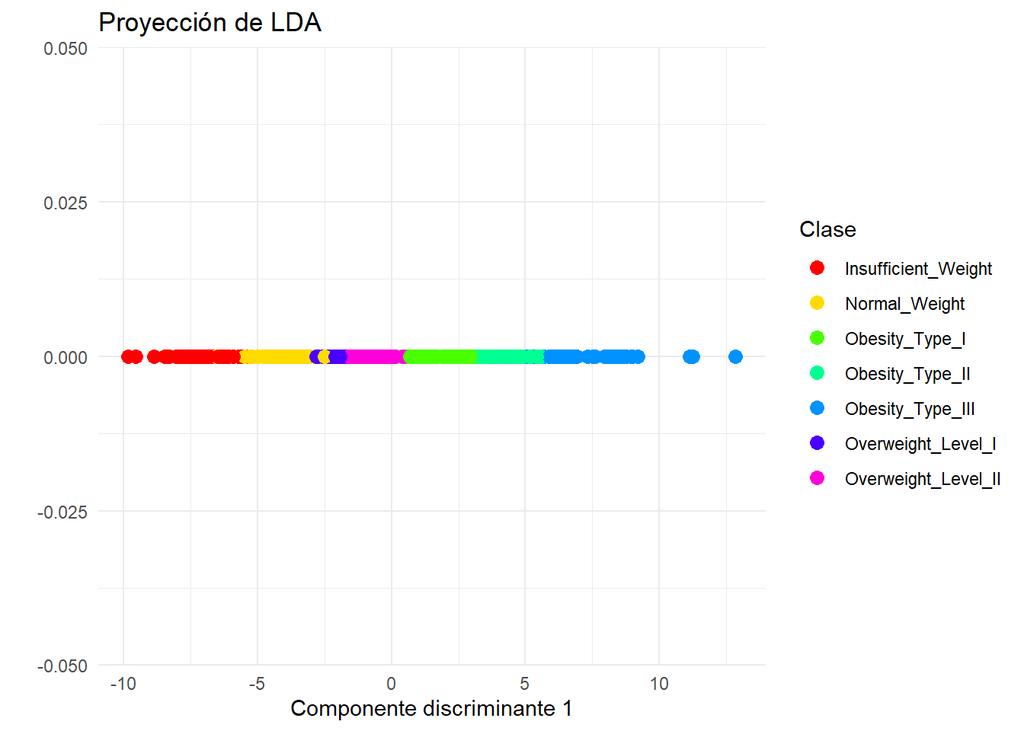

```r
lda_train <- data.frame(Componente_1 = pred_lda$x[, 1], Clase = test.df$NObeyesdad)

ggplot(lda_train, aes(x = Componente_1, y = 0, color = Clase)) +
  geom_point(size = 3) +
  labs(
    title = "Proyección de LDA",
    x = "Componente discriminante 1",
    y = ""
  ) +
  theme_minimal() +
  scale_color_manual(values = rainbow(length(unique(lda_train$Clase))))
```

Como hemos podido ver en la matriz de confusión las distintas clases del tipo de obesidad se pueden ver bastante bien, además de poder verse como colosiona una clase con otra, confundiendose en parte de clase, por lo que puede ser un buen modelo para poder compararlo con otros. A continuación vamos a ver los distintos discriminantes y los vamos a nalizar.

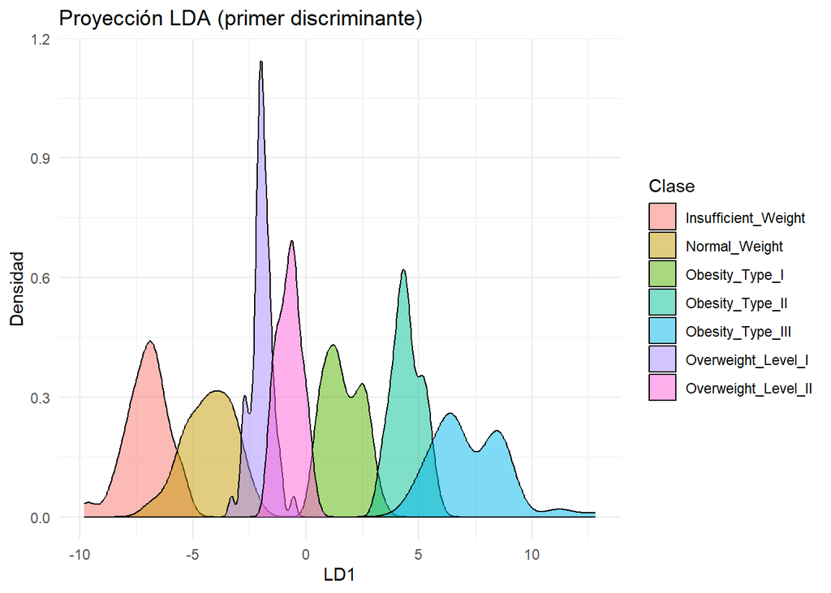

```r
proj <- data.frame(
  LD1 = pred_lda$x[, 1],
  Clase = test.df$NObeyesdad
)

ggplot(proj, aes(x = LD1, fill = Clase)) +
  geom_density(alpha = 0.5) +
  labs(title = "Proyección LDA (primer discriminante)",
       x = "LD1", y = "Densidad") +
  theme_minimal()
```

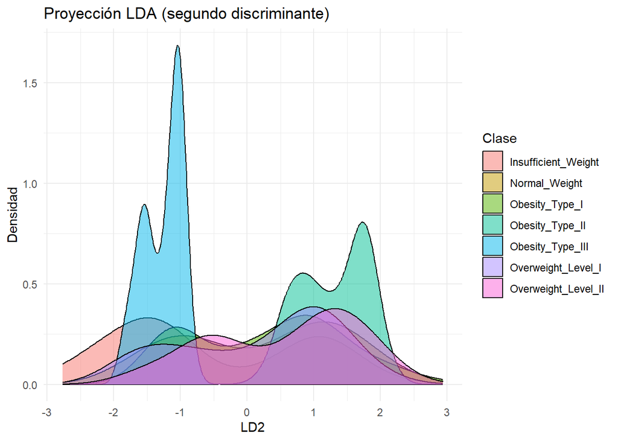

```r
proj <- data.frame(
  LD2 = pred_lda$x[, 2],
  Clase = test.df$NObeyesdad
)

ggplot(proj, aes(x = LD2, fill = Clase)) +
  geom_density(alpha = 0.5) +
  labs(title = "Proyección LDA (segundo discriminante)",
       x = "LD2", y = "Densidad") +
  theme_minimal()
```

En este segundo discriminante, se ve que las clases estan más juntas, incluso superpuestas, sin embargo vemos que las clases de Obesity_Type_II y Obesity_Type_III estan bastante separadas, además de tener las mayores densidades lo que puede indicar que para este discriminante son las más importantes.

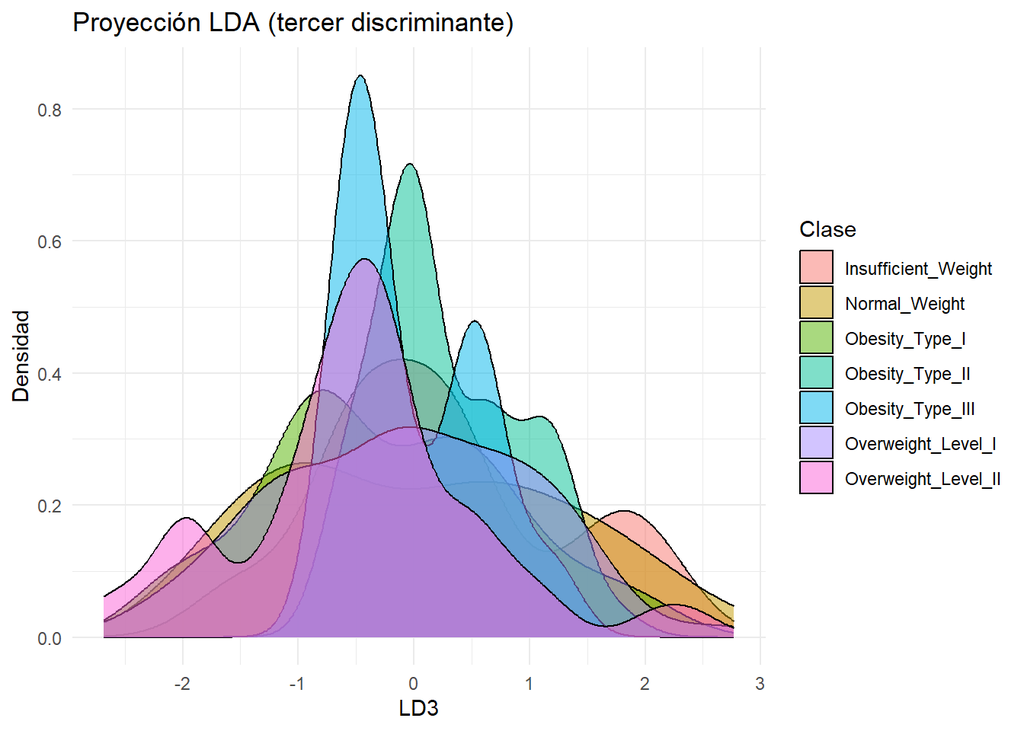

```r
proj <- data.frame(
  LD3 = pred_lda$x[, 3],
  Clase = test.df$NObeyesdad
)

ggplot(proj, aes(x = LD3, fill = Clase)) +
  geom_density(alpha = 0.5) +
  labs(title = "Proyección LDA (tercer discriminante)",
       x = "LD3", y = "Densidad") +
  theme_minimal()
```

En este tercer discriminante, podemos ver como todas las clases están más o menos centradas, además de que se podría decir que siguien una distribución normal de media 0 (aproximadamente), por lo que podemos concluir que par este discriminante las variables se han normalizado.

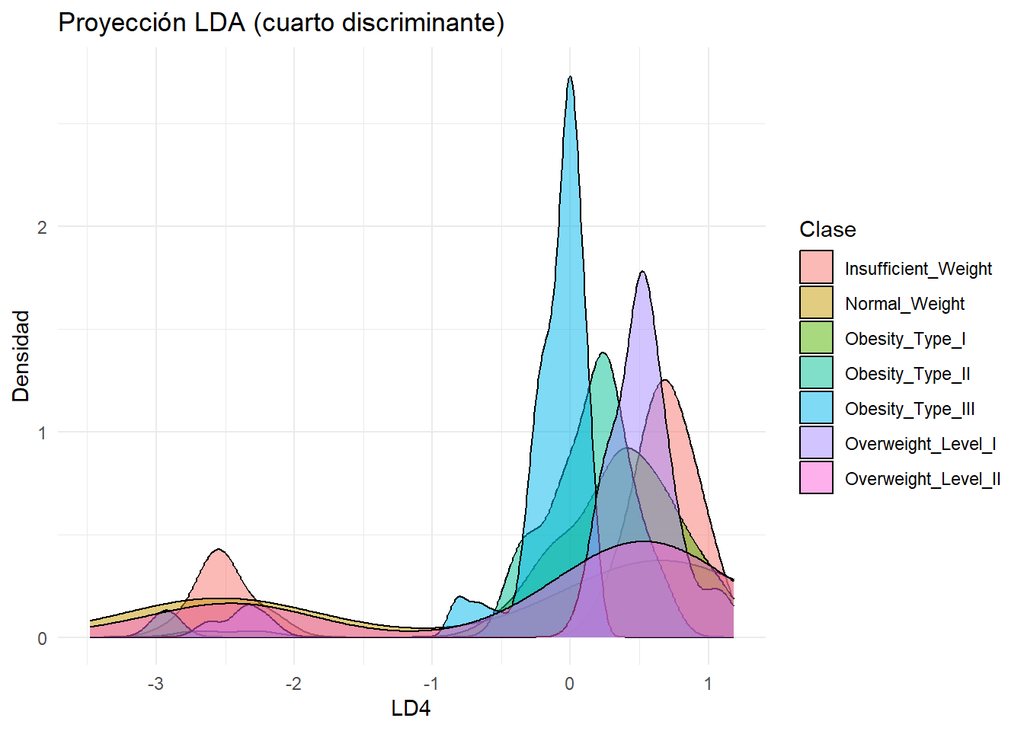

```r
proj <- data.frame(
  LD4 = pred_lda$x[, 4],
  Clase = test.df$NObeyesdad
)

ggplot(proj, aes(x = LD4, fill = Clase)) +
  geom_density(alpha = 0.5) +
  labs(title = "Proyección LDA (cuarto discriminante)",
       x = "LD4", y = "Densidad") +
  theme_minimal()
```

En este discriminante, se pueden ver distintos grupos, en los cuales en ambos hay de todos los tipos de clases, podemos ver que en este discriminante lo que se ha hecho ha sido separa según dos parámetros que no sabemos exactamente cuales son.

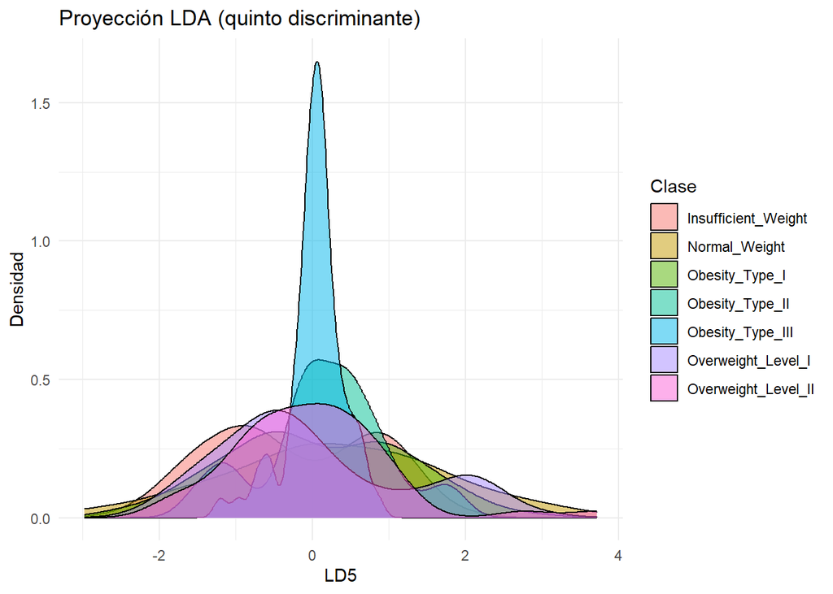

```r
proj <- data.frame(
  LD5 = pred_lda$x[, 5],
  Clase = test.df$NObeyesdad
)

ggplot(proj, aes(x = LD5, fill = Clase)) +
  geom_density(alpha = 0.5) +
  labs(title = "Proyección LDA (quinto discriminante)",
       x = "LD5", y = "Densidad") +
  theme_minimal()
```

Este discriminante no sabemos muy bien que es lo que puede significar, para ello, necesitariamos al experto que nos ayudase a poder comprender esta nueva variable para poder hacer mejores predicciones.

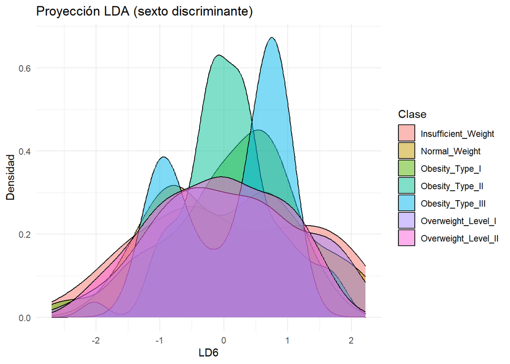

```r
proj <- data.frame(
  LD6 = pred_lda$x[, 6],
  Clase = test.df$NObeyesdad
)

ggplot(proj, aes(x = LD6, fill = Clase)) +
  geom_density(alpha = 0.5) +
  labs(title = "Proyección LDA (sexto discriminante)",
       x = "LD6", y = "Densidad") +
  theme_minimal()
```

Con esta nos pasa lo mismo que con el discriminante anterior. A continuación vamos a ver las medidas que necesitamos para poder compara los modelos.

```r
predicciones <- as.factor(pred_lda$class)
test.df$NObeyesdad <- as.factor(test.df$NObeyesdad)

# Calculamos las métricas
resultados <- confusionMatrix(predicciones, test.df$NObeyesdad, positive = "ClasePositiva")  # Especificar la clase positiva
print(resultados)
```

```
## Confusion Matrix and Statistics
##
##                      Reference
## Prediction            Insufficient_Weight Normal_Weight Obesity_Type_I
##   Insufficient_Weight                  55             4              0
##   Normal_Weight                         7            33              0
##   Obesity_Type_I                        0             0             78
##   Obesity_Type_II                       0             0              5
##   Obesity_Type_III                      0             0              0
##   Overweight_Level_I                    0             7              0
##   Overweight_Level_II                   0             0              2
##                      Reference
## Prediction            Obesity_Type_II Obesity_Type_III Overweight_Level_I
##   Insufficient_Weight               0                0                  0
##   Normal_Weight                     0                0                  1
##   Obesity_Type_I                    1                0                  0
##   Obesity_Type_II                  54                1                  0
##   Obesity_Type_III                  0               67                  0
##   Overweight_Level_I                0                0                 50
##   Overweight_Level_II               0                0                  7
##                      Reference
## Prediction            Overweight_Level_II
##   Insufficient_Weight                   0
##   Normal_Weight                         0
##   Obesity_Type_I                        1
##   Obesity_Type_II                       0
##   Obesity_Type_III                      0
##   Overweight_Level_I                    9
##   Overweight_Level_II                  40
##
## Overall Statistics
##
##                Accuracy : 0.8934
##                  95% CI : (0.8599, 0.9211)
##     No Information Rate : 0.2014
##     P-Value [Acc > NIR] : < 2.2e-16
##
##                   Kappa : 0.8748
##
##  Mcnemar's Test P-Value : NA
```

[output cut: 24 more lines]

```
## Pos Pred Value                        1.0000                    0.7576
## Neg Pred Value                        0.9972                    0.9775
## Prevalence                            0.1611                    0.1374
## Detection Rate                        0.1588                    0.1185
## Detection Prevalence                  0.1588                    0.1564
## Balanced Accuracy                     0.9926                    0.9091
##                      Class: Overweight_Level_II
## Sensitivity                             0.80000
## Specificity                             0.97581
## Pos Pred Value                          0.81633
## Neg Pred Value                          0.97319
## Prevalence                              0.11848
## Detection Rate                          0.09479
## Detection Prevalence                    0.11611
## Balanced Accuracy                       0.88790
```

Con estas medidas, podemos ver bastantes cosas muy interesantes, primero de todo es el nivel de accuracy, que como ya habiamos visto antes tiene un valor de 0.89, lo que nos da bastante explicabilidad, además de que el p-vamor es lo suficiente pequiño como para que el modelo sea bastante bueno.

Por oro lado tenemos las distintas mediad que podemos ver como en la sensibilidad, la tasa de veces que acertamos cuando tenemso que acertar la clase es bastante alta, estnado en la mayoría con un valor caso de 0.9, lo que nos puede indicar que puede diferenciar bien las clases.

Pro otro lado, tenemos la tasa de verdaderos negativos, que es incluso mejor, como podemos ver el valor mínimo es de 0.95, lo que nos indica que sabe difernciar bien si una observacion va en una clase o no, dandonos un buen modelo de clasificación.

Por otro lado los valores predichos, tanto positivos como negativos nos dan bastante altos, dandonos bastante explicabilidad a los datos. Por último tenemos la precisión balancead inidcandonos la exactitud con la que se predice en cada clase, por lo que se ve es bastante alta, lo que nos dice que es bastante buena.

Sin embargo, aunque tengamos un muy buen modeo de clasificación no cumple el supuesto de normalidad multivariante que tiene que cumplir para poder aplicar lda, lo que nos da un modelo bastante bueno para compara con otros.

Para concluir, vamos a comparar el modelo que hemos creado a manos siguiendo la siguiente fórmula:
$$\delta_{c}(\mathbf{x})=\mathbf{x}^{t} \Sigma^{-1}\mu_{c}
-\frac{1}{2}\mu_{c}^{t}\Sigma^{-1}\mu_{c} + \log(P(Y=c))$$

```r
source("Memoria_Funciones.R")
```

```
## Accuracy en test: 41.47%
```

```r
train_num <- train.df |> dplyr::select(where(is.numeric))
test_num <- test.df |> dplyr::select(where(is.numeric))

# Entrena el modelo
modelo_lda <- mi_lda(X = train_num, y = train.df$NObeyesdad)

# Haz predicciones
pred_manual <- predict(modelo_lda, test_num)

# Matriz de confusión
table(Predicho = pred_manual, Real = test.df$NObeyesdad)
```

```
##                      Real
## Predicho              Insufficient_Weight Normal_Weight Obesity_Type_I
##   Insufficient_Weight                  56             5              0
##   Normal_Weight                         6            32              0
##   Obesity_Type_I                        0             0             76
##   Obesity_Type_II                       0             0              7
##   Obesity_Type_III                      0             0              0
##   Overweight_Level_I                    0             7              0
##   Overweight_Level_II                   0             0              2
##                      Real
## Predicho              Obesity_Type_II Obesity_Type_III Overweight_Level_I
##   Insufficient_Weight               0                0                  0
##   Normal_Weight                     0                0                  1
##   Obesity_Type_I                    0                0                  0
##   Obesity_Type_II                  55                1                  0
##   Obesity_Type_III                  0               67                  0
##   Overweight_Level_I                0                0                 53
##   Overweight_Level_II               0                0                  4
##                      Real
## Predicho              Overweight_Level_II
##   Insufficient_Weight                   0
##   Normal_Weight                         0
##   Obesity_Type_I                        0
##   Obesity_Type_II                       0
##   Obesity_Type_III                      0
##   Overweight_Level_I                   14
##   Overweight_Level_II                  36
```

```r
# Precisión manual
lda_manual <- mean(pred_manual == test.df$NObeyesdad)
```

```r
print(confusion)
```

```
##                      Actual
## Predicted             Insufficient_Weight Normal_Weight Obesity_Type_I
##   Insufficient_Weight                  55             4              0
##   Normal_Weight                         7            33              0
##   Obesity_Type_I                        0             0             78
##   Obesity_Type_II                       0             0              5
##   Obesity_Type_III                      0             0              0
##   Overweight_Level_I                    0             7              0
##   Overweight_Level_II                   0             0              2
##                      Actual
## Predicted             Obesity_Type_II Obesity_Type_III Overweight_Level_I
##   Insufficient_Weight               0                0                  0
##   Normal_Weight                     0                0                  1
##   Obesity_Type_I                    1                0                  0
##   Obesity_Type_II                  54                1                  0
##   Obesity_Type_III                  0               67                  0
##   Overweight_Level_I                0                0                 50
##   Overweight_Level_II               0                0                  7
##                      Actual
## Predicted             Overweight_Level_II
##   Insufficient_Weight                   0
##   Normal_Weight                         0
##   Obesity_Type_I                        1
##   Obesity_Type_II                       0
##   Obesity_Type_III                      0
##   Overweight_Level_I                    9
##   Overweight_Level_II                  40
```

Como podemos ver en la comparación, el modelo hecho a mano predice de forma similar al que hemos hecho con lda de r.

### Árboles de decisión

Este método es bastante fácil de interpretar, maneja tanto datos numéricos como categóricos, es bastante efectivo cuando las relaciones entre las variables no son lineales y nos ayuda a entender como cada característica afecta las decisiones del modelo, aunque puede acabar sobreajustando.

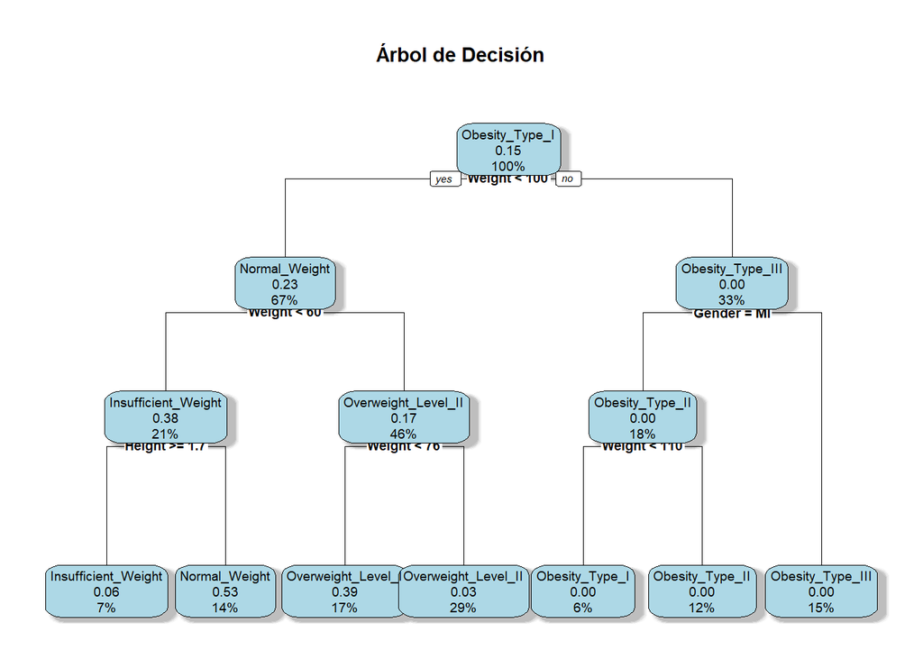

```r
set.seed(1)
df <- train %>%
      dplyr::select(Gender, Height, Weight, family_history_with_overweight, FAVC, FAF, MTRANS, NObeyesdad)
fit.dt <- rpart(NObeyesdad~., data = df, method = 'class', control = rpart.control(maxdepth = 3))
rpart.plot(fit.dt,
           extra = 106,
           cex = 0.6,
           type = 2,
           box.palette = "RdYlBu",
           shadow.col = "gray",
           main = "Árbol de Decisión",
           box.col = "lightblue",
           faclen = 2)
```

Hemos reducido la profundidad y por tanto la compliejidad del modelo y aumentada la explicabilidad.

Vamos a explicar el diagrama de arbol desde el nodo raíz hasta los nodos hoja:

El árbol empieza en el nodo raíz separando en 2 nodos dependiendo de la condición de si el peso es mayor de 100 (Obesidad tipo 3) o menor de 100 (peso normal), representando cada nodo el 33% y el 66% de los datos de entrenamiento respectivamente.

```r
prediction <- predict(fit.dt, train, type = 'class')
cf <- confusionMatrix(prediction, as.factor(train$NObeyesdad),positive="yes")
print(cf)
```

```
## Confusion Matrix and Statistics
##
##                      Reference
## Prediction            Insufficient_Weight Normal_Weight Obesity_Type_I
##   Insufficient_Weight                  81             5              0
##   Normal_Weight                        76            94              0
##   Obesity_Type_I                        0             0             52
##   Obesity_Type_II                       0             0              4
##   Obesity_Type_III                      0             0              0
##   Overweight_Level_I                    4            86              2
##   Overweight_Level_II                   0            11            141
##                      Reference
## Prediction            Obesity_Type_II Obesity_Type_III Overweight_Level_I
##   Insufficient_Weight               0                0                  0
##   Normal_Weight                     0                0                  6
##   Obesity_Type_I                   24                0                  0
##   Obesity_Type_II                 148                0                  0
##   Obesity_Type_III                  0              188                  0
##   Overweight_Level_I                0                0                102
##   Overweight_Level_II               5                0                 64
##                      Reference
## Prediction            Overweight_Level_II
##   Insufficient_Weight                   0
##   Normal_Weight                         0
##   Obesity_Type_I                        2
##   Obesity_Type_II                       0
##   Obesity_Type_III                      0
##   Overweight_Level_I                   27
##   Overweight_Level_II                 144
##
## Overall Statistics
##
##                Accuracy : 0.639
##                  95% CI : (0.6119, 0.6655)
##     No Information Rate : 0.1572
##     P-Value [Acc > NIR] : < 2.2e-16
##
##                   Kappa : 0.5794
##
##  Mcnemar's Test P-Value : NA
```

[output cut: 24 more lines]

```
## Pos Pred Value                        1.0000                   0.46154
## Neg Pred Value                        1.0000                   0.93301
## Prevalence                            0.1485                   0.13586
## Detection Rate                        0.1485                   0.08057
## Detection Prevalence                  0.1485                   0.17457
## Balanced Accuracy                     1.0000                   0.74212
##                      Class: Overweight_Level_II
## Sensitivity                              0.8324
## Specificity                              0.7978
## Pos Pred Value                           0.3945
## Neg Pred Value                           0.9678
## Prevalence                               0.1367
## Detection Rate                           0.1137
## Detection Prevalence                     0.2883
## Balanced Accuracy                        0.8151
```

Medidas de rendimiento usadas en el modelo:

La matriz de confusión, sensibilidad y especificidad (cuán bien detecta y descarta cada clase) y el valor Accuracy.

Estas métricas nos permiten ver el modelo desde varios ángulos: la matriz de confusión nos muestra con detalle sus aciertos y errores; la sensibilidad y la especificidad nos dicen qué tan bien identifica correctamente cada tipo de obesidad; el valor predictivo positivo y negativo nos da la confianza real que podemos tener en las predicciones y el valor Accuracy nos garantiza que el rendimiento global del modelo equilibre de manera justa la detección de casos con el descarte correcto de los no afectados.

Con todo esto no solo comprobamos que el modelo sea preciso, sino que lo haga de manera equilibrada y fiable.

### Métodos de Ensamblado

Aplicando métodos de ensamblado, podemos mejorar significativamente el rendimiento de predicción, ya que se basa en la unión de múltiples modelos, comenzaremos aplicando el esamblado de bagging.

#### Bagging

```r
rf <- randomForest(as.factor(NObeyesdad)~., data=train, importance=TRUE,proximity=TRUE)
print(rf)
```

```
##
## Call:
##  randomForest(formula = as.factor(NObeyesdad) ~ ., data = train,      importance = TRUE, proximity = TRUE)
##                Type of random forest: classification
##                      Number of trees: 500
## No. of variables tried at each split: 4
##
##         OOB estimate of  error rate: 4.82%
## Confusion matrix:
##                     Insufficient_Weight Normal_Weight Obesity_Type_I
## Insufficient_Weight                 151            10              0
## Normal_Weight                         1           187              0
## Obesity_Type_I                        0             0            193
## Obesity_Type_II                       0             1              0
## Obesity_Type_III                      0             0              0
## Overweight_Level_I                    0            22              0
## Overweight_Level_II                   0             4              2
##                     Obesity_Type_II Obesity_Type_III Overweight_Level_I
## Insufficient_Weight               0                0                  0
## Normal_Weight                     0                0                  5
## Obesity_Type_I                    1                0                  2
## Obesity_Type_II                 176                0                  0
## Obesity_Type_III                  0              188                  0
## Overweight_Level_I                0                0                146
## Overweight_Level_II               0                0                  3
##                     Overweight_Level_II class.error
## Insufficient_Weight                   0 0.062111801
## Normal_Weight                         3 0.045918367
## Obesity_Type_I                        3 0.030150754
## Obesity_Type_II                       0 0.005649718
## Obesity_Type_III                      0 0.000000000
## Overweight_Level_I                    4 0.151162791
## Overweight_Level_II                 164 0.052023121
```

Continuamos evaluando visualmente la convergencia del modelo, para analizar el comportamiento del modelo según se agregan árboles al conjunto.

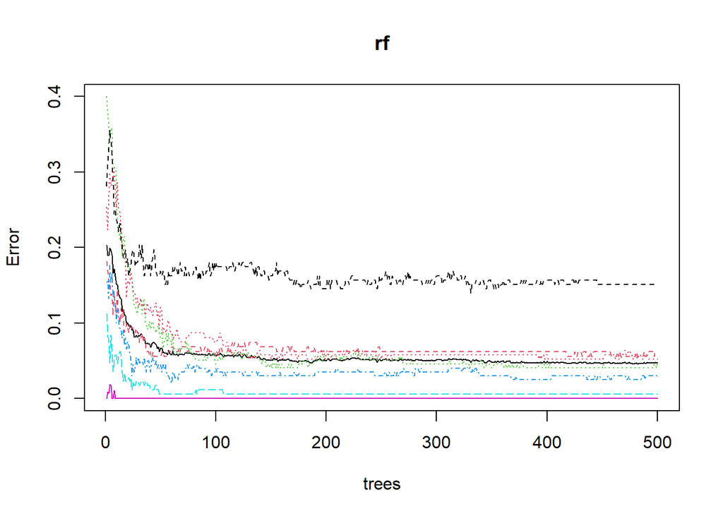

```r
plot(rf)
```

A continuación, identificamos las variables predictoras que más influyen en las decisiones del modelo:

```r
importance(rf)
```

```
##                                Insufficient_Weight Normal_Weight Obesity_Type_I
## Gender                                   16.916766    10.8895092     26.6102736
## Age                                      30.836277    14.2868139     31.2263810
## Height                                   27.919496    19.8909040     45.7078739
## Weight                                   87.917600    57.8206985     78.1651206
## family_history_with_overweight           22.501008     7.4205343     22.8287509
## FAVC                                      9.870765     0.5054552     14.1276143
## FCVC                                     21.252337    12.6994459     26.2920645
## NCP                                      23.589581     7.8706646     25.0131301
## CAEC                                     25.547552    15.5903809     23.2080603
## SMOKE                                     3.010615     1.0665225      0.6854747
## CH2O                                     15.688805    14.2687974     21.6670609
## SCC                                       1.781440    -3.0042597      3.1235043
## FAF                                      14.431231    12.1346345     18.0537799
## TUE                                      22.256371    10.0908143     20.0261147
## CALC                                     17.160326    -2.2803215     20.3770463
## MTRANS                                   16.727266     2.3701211     13.5479914
##                                Obesity_Type_II Obesity_Type_III
## Gender                              24.2839596       36.0149092
## Age                                 31.2112544       15.1271280
## Height                              17.1890719       11.9957553
## Weight                             113.6659189       63.6649120
## family_history_with_overweight      14.3262718       13.8814420
## FAVC                                 6.1736257        5.7387187
## FCVC                                23.0838079       29.6986568
## NCP                                 20.6611968       12.5904708
## CAEC                                12.5211137       12.5283352
## SMOKE                                0.8945704        0.5163508
## CH2O                                21.6664407        7.7586811
## SCC                                  2.2379100        2.6905012
## FAF                                 16.0289546       10.8736703
## TUE                                 12.3596563       15.2351092
## CALC                                15.6780009       12.0793131
## MTRANS                               7.8370533       10.3196443
##                                Overweight_Level_I Overweight_Level_II
## Gender                                  18.697352           21.009214
## Age                                     35.555326           33.965846
## Height                                  38.127606           42.546401
## Weight                                  66.160995           65.545508
## family_history_with_overweight          19.933479           20.482863
```

[output cut: 13 more lines]

```
## Age                                       43.571994        97.816903
## Height                                    50.069660       108.901434
## Weight                                   116.379525       380.742111
## family_history_with_overweight            26.573509        30.445144
## FAVC                                      23.732350        17.051411
## FCVC                                      34.619841        92.228920
## NCP                                       33.803704        52.939480
## CAEC                                      29.725956        38.548726
## SMOKE                                      5.091986         1.763868
## CH2O                                      36.650486        44.648674
## SCC                                        9.865814         4.185999
## FAF                                       27.712202        45.927305
## TUE                                       28.041159        47.192575
## CALC                                      26.062412        33.385181
## MTRANS                                    23.020990        21.221569
```

Esta función nos muestra dos medidas clave:

Mean Decrease Accuracy: Muestra cuánto disminuye la precisión del modelo excluimos cada variable.

Mean Decrease Ginni: Mide la pureza de los nodos que aporta cada variable al dividir los datos.

Junto al peso, tenemos las variables Altura y Edad, que también son de las más importantes ya que sus valores son los siguientes mas elevados, y por ello también son variables muy relevantes al predecir el nivel de obesidad. También cabe descatar la importancia de ciertas variables como family_history_with_overweight y FCVC, sus valores también son relevantes y esto nos indica que el historial familiar de obesidad y la frecuencia en el consumo de vegetales también tienen una contribución relevante en el modelo.

Por el contrario, variables como SMOKE O SCC, presentan valores muy bajos e incluso negativos, lo que nos sugiere que son poco relevantes a la hora de predecir el nivel de obesidad. Lo cual concuerda con conclusiones anteriores en las que afirmamos que la variable fumar no afecta al nivel de obesidad.

Evaluamos la importancia de las variables:

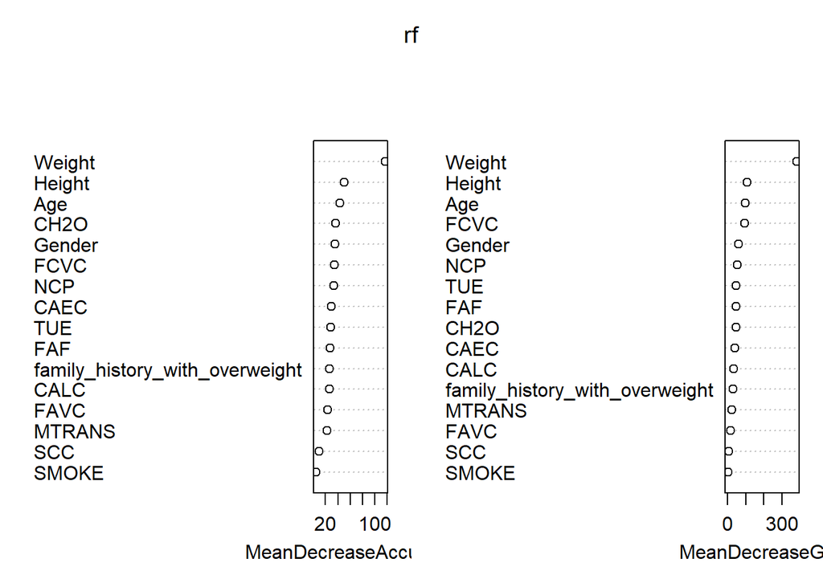

```r
varImpPlot(rf)
```

Al representar graficamente las Mean Decrease Accurancy y Mean Decrease Gini podemos observar de manera más visual como la variables más importante es el peso, lo cual tiene sentido ya que el nivel de obesidad depende del peso. En ambas métricas destacan también de manera muy notable la altura y la edad. Además la frecuencia en el consumo de verduras, el consumo de agua (CH2O) y la frecuencia del consumo de comida calórica (CAEC), también son relevantes, lo que nos puede llevar a concluir la importancia de los hábitos alimenticios en el peso. Por último y coincidencio con lo anterior SCC Y SMOKE vuelven a tener el impacto menos notable en la predicción del modelo.

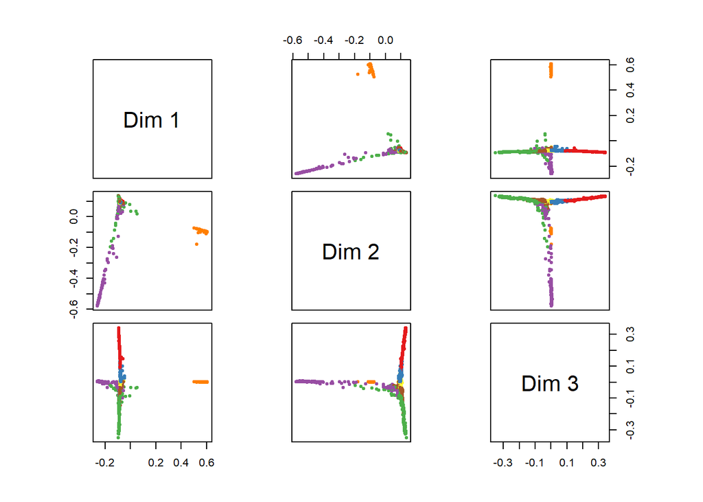

```r
MDSplot(rf,as.factor(train$NObeyesdad),k=3)
```

```r
vars <- setdiff(names(train), "NObeyesdad")

df.test <- test[, vars]
for (v in vars) {
  if (is.factor(train[[v]])) {
    df.test[[v]] <- factor(df.test[[v]], levels = levels(train[[v]]))
  } else {
    df.test[[v]] <- as.numeric(df.test[[v]])
  }
}

#Hacemos predicción
prediction.rf <- predict(rf, df.test)

#Creamos factores con niveles iguales para comparación
niveles <- levels(train$NObeyesdad)
prediction.rf <- factor(prediction.rf, levels = niveles)
real.rf <- factor(test$NObeyesdad, levels = niveles)

# Matriz de confusión
cf <- confusionMatrix(prediction.rf, real.rf)
print(cf)
```

```
## Confusion Matrix and Statistics
##
##                      Reference
## Prediction            Insufficient_Weight Normal_Weight Obesity_Type_I
##   Insufficient_Weight                  56             0              0
##   Normal_Weight                         6            42              2
##   Obesity_Type_I                        0             0             82
##   Obesity_Type_II                       0             0              0
##   Obesity_Type_III                      0             0              0
##   Overweight_Level_I                    0             2              1
##   Overweight_Level_II                   0             0              0
##                      Reference
## Prediction            Obesity_Type_II Obesity_Type_III Overweight_Level_I
##   Insufficient_Weight               0                0                  0
##   Normal_Weight                     0                0                  4
##   Obesity_Type_I                    0                0                  0
##   Obesity_Type_II                  55                0                  0
##   Obesity_Type_III                  0               68                  0
##   Overweight_Level_I                0                0                 52
##   Overweight_Level_II               0                0                  2
##                      Reference
## Prediction            Overweight_Level_II
##   Insufficient_Weight                   0
##   Normal_Weight                         4
##   Obesity_Type_I                        1
##   Obesity_Type_II                       0
##   Obesity_Type_III                      0
##   Overweight_Level_I                    0
##   Overweight_Level_II                  45
##
## Overall Statistics
##
##                Accuracy : 0.9479
##                  95% CI : (0.9221, 0.967)
##     No Information Rate : 0.2014
##     P-Value [Acc > NIR] : < 2.2e-16
##
##                   Kappa : 0.9388
##
##  Mcnemar's Test P-Value : NA
```

[output cut: 24 more lines]

```
## Pos Pred Value                        1.0000                    0.9455
## Neg Pred Value                        1.0000                    0.9837
## Prevalence                            0.1611                    0.1374
## Detection Rate                        0.1611                    0.1232
## Detection Prevalence                  0.1611                    0.1303
## Balanced Accuracy                     1.0000                    0.9442
##                      Class: Overweight_Level_II
## Sensitivity                              0.9000
## Specificity                              0.9946
## Pos Pred Value                           0.9574
## Neg Pred Value                           0.9867
## Prevalence                               0.1185
## Detection Rate                           0.1066
## Detection Prevalence                     0.1114
## Balanced Accuracy                        0.9473
```

En el conjunto de entrenamiento, el modelo mostraba un rendimiento casi excelente, con un accuracy del 95%o más, y siendo los errores mínimos. Sin embargo, al ajustarlo al conjunto de prueba, aunque el desempeño siga siendo alto podemos observar una ligera caída y aunque sigue sugiriendo que generaliza bien, podría ester sobreajustando brevemente.

En cuanto a la medidas de rendimiento, indican que el modelo clasifica correctamente la mayoria de categorías, destacando obesidad de nivel 3, que alcanza valores perfectos de sensibilidad, especificidad y precisión. Sin embargo, clases como Sobre Peso de Nivel 2 y Peso Normal, presentan menor sensibilidad y precisión, por lo que el modelo tiene más dificultad para distinguir entre clases cercanaso con menos representación. En conjunto, balanced accuracy y F1_score confirman un rendimiento global sólido, aunque con margen de mejora en clases específicas.

Ahora vamos a comparar el método bagging con la función propia de R, con el método programado a continuación:

Cargamos la función desde el archivo de funciones:

```r
source("Memoria_Funciones.R")
```

```
## Accuracy en test: 41.47%
```

```r
# Entrenamos el bagging manual con 500 árboles
modelo_bagging <- bagging_manual(train, "NObeyesdad", n_trees = 500)

# Obtenemos predicciones usando solo los árboles en los que la observación fue OOB
pred_oob <- prediccion_oob(modelo_bagging$modelos, modelo_bagging$oob, train)

# Quitamos los NA (observaciones que ningún árbol dejó fuera)
idx_validos <- !is.na(pred_oob)

# Evaluamos la precisión sobre las observaciones OOB
matriz <- confusionMatrix(pred_oob[idx_validos], train$NObeyesdad[idx_validos])

print(matriz)
```

```
## Confusion Matrix and Statistics
##
##                      Reference
## Prediction            Insufficient_Weight Normal_Weight Obesity_Type_I
##   Insufficient_Weight                 152            14              0
##   Normal_Weight                         9           147              0
##   Obesity_Type_I                        0             0            182
##   Obesity_Type_II                       0             0              7
##   Obesity_Type_III                      0             0              0
##   Overweight_Level_I                    0            31              2
##   Overweight_Level_II                   0             4              8
##                      Reference
## Prediction            Obesity_Type_II Obesity_Type_III Overweight_Level_I
##   Insufficient_Weight               0                0                  0
##   Normal_Weight                     0                0                 11
##   Obesity_Type_I                    7                0                  0
##   Obesity_Type_II                 170                0                  0
##   Obesity_Type_III                  0              188                  0
##   Overweight_Level_I                0                0                146
##   Overweight_Level_II               0                0                 15
##                      Reference
## Prediction            Overweight_Level_II
##   Insufficient_Weight                   0
##   Normal_Weight                         1
##   Obesity_Type_I                       15
##   Obesity_Type_II                       0
##   Obesity_Type_III                      0
##   Overweight_Level_I                   20
##   Overweight_Level_II                 137
##
## Overall Statistics
##
##                Accuracy : 0.8863
##                  95% CI : (0.8675, 0.9032)
##     No Information Rate : 0.1572
##     P-Value [Acc > NIR] : < 2.2e-16
##
##                   Kappa : 0.8672
##
##  Mcnemar's Test P-Value : NA
```

[output cut: 24 more lines]

```
## Pos Pred Value                        1.0000                    0.7337
## Neg Pred Value                        1.0000                    0.9756
## Prevalence                            0.1485                    0.1359
## Detection Rate                        0.1485                    0.1153
## Detection Prevalence                  0.1485                    0.1572
## Balanced Accuracy                     1.0000                    0.9002
##                      Class: Overweight_Level_II
## Sensitivity                              0.7919
## Specificity                              0.9753
## Pos Pred Value                           0.8354
## Neg Pred Value                           0.9673
## Prevalence                               0.1367
## Detection Rate                           0.1082
## Detection Prevalence                     0.1295
## Balanced Accuracy                        0.8836
```

Por tanto, podemos concluir que el bagging programado manualmente es eficaz y ajusta bien, pero el modelo automático es mejor, ya que es mas exacto y está más equilibrado.

#### Boosting

A diferencia del Bagging, que entrena múltiples modelos en paralelo y los promedia, boosting entrena múltiples modelos en serie, es decir, **de manera secuencial**.

Haciendolo de esta manera, se da mayor peso a aquellas observaciones mal clasificadas en cada iteracción para intentar que el siguiente modelo aprenda a clasificar bien esas observaciones.

Vamos a aplicar el modelo XGBoost.

```r
# Convertimos los datos a numéricos
df.train <- map_df(train, function(columna) {
  columna %>%
    as.factor() %>%
    as.numeric %>%
    { . - 1 }
})

datos <- list()
datos$train <- df.train

df.test <- map_df(test, function(columna) {
  columna %>%
    as.factor() %>%
    as.numeric %>%
    { . - 1 }
})

datos$test <- df.test


# Convertimos los datos al formato Dmatrix
datos$train_mat  <-
  datos$train %>%
  dplyr::select(-NObeyesdad) %>%
  as.matrix() %>%
  xgboost::xgb.DMatrix(data = ., label = datos$train$NObeyesdad)
datos$test_mat  <-
  datos$test %>%
  dplyr::select(-NObeyesdad) %>%
  as.matrix() %>%
  xgboost::xgb.DMatrix(data = ., label = datos$test$NObeyesdad)

# Parámetros
params <- list(
  objective = "multi:softmax",  # Porque nuestra variable de NObeyesdad es multiclase
  num_class = 7,                # Numero de clases
  eval_metric = "mlogloss"
)

datos$modelo_01 <- xgboost(params= params,
                           data = datos$train_mat,
                           nround = 10,
                           max_depth=2,
                           eta =0.3,
                           nthread =2)
xgb.plot.multi.trees(model = datos$modelo_01)
```

```
## Column 2 ['No'] of item 2 is missing in item 1. Use fill=TRUE to fill with NA (NULL for list columns), or use.names=FALSE to ignore column names. use.names='check' (default from v1.12.2) emits this message and proceeds as if use.names=FALSE for  backwards compatibility. See news item 5 in v1.12.2…
```

[interactive chart not shown]

Vamos a explicar el árbol.

La parte superior del árbol está a la izquierda y la parte inferior a la derecha. Los números que salen al lado de cada variable es la calidad, la importancia de esa característica en el árbol.

Entonces, es muy fácil ver que la característica más importante de todas es con diferencia, Weight, el peso de cada individuo.

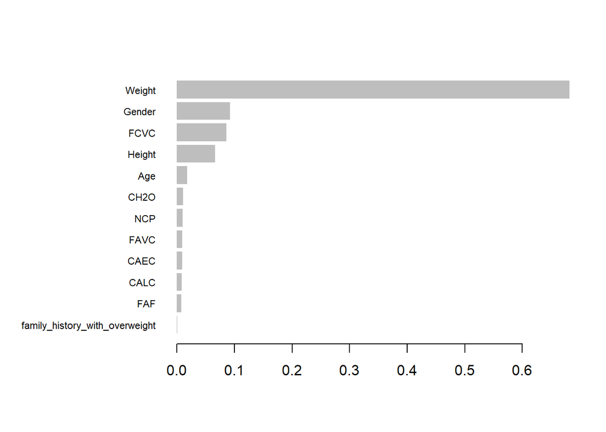

```r
importance_matrix <- xgb.importance(model = datos$modelo_01)

xgb.plot.importance(importance_matrix)
```

Gracias a este histograma, observamos que las características más importantes en orden de mayor a menor importancia son el peso, el género, la frecuencia de consumo de verduras, la altura y la edad, pero principalmente el peso del indivuduo, como era de esperar puesto que está muy relacionada con la variable NObeyesdad, que es la variable que tenemos que predecir.

```r
preds <- predict(datos$modelo_01, datos$test_mat)
accuracy <- mean(preds == datos$test$NObeyesdad)

cat(sprintf("Accuracy en test: %.2f%%\n", accuracy * 100))
```

```
## Accuracy en test: 15.88%
```

Finalmente, el rendimiento de este modelo de Boosting es de 16% aproximadamente, lo que no nos es un modelo útil para nuestro conjunto de datos.

En conclusión, los resultados obtenidos del algoritmo implementado es mucho más eficiente (valor de Accuracy de 40% aproximadamente) ya que las iteraciones y bucles son controladas, el propio algoritmo está personalizado a nuestro caso concreto y hemos ajustado los parámetros para nuestro ejemplo concreto.

Medidas de rendimiento utilizadas:

### Random Forest

Es una técnica de ensamblado que mejora la precisión de las predicciones. Se construye un bosque formado por varios árboles de decisión individuales no necesariamente correlacionados. Vamos a explicar un poco como funciona el algorítmo:

1. Iniciación: Definir los parámetros (número de árboles, tamaño de los nodos, etc)
2. Creación de cada árbol: Tomar una muestra bootstrap de tamaño n del conjunto de entrenamiento y crear un árbol usando esa muestra.
- Selección de variables: seleccionar un pequeño conjunto de las variables.
- Cálculo de la mejor división: para las variables seleccionadas, escoger la mejor variable y la mejor división.
- División del nodo: Dividir el nodo en 2 nodos hijos en función de la variable seleccionada y la mejor división.
- Recursión: Repetir el proceso de división recursivamente para cada nodo hijo hasta que se alcance un criterio de detención.
3. Output y división: devolver el ensamblado de árboles para hacer una predicción total

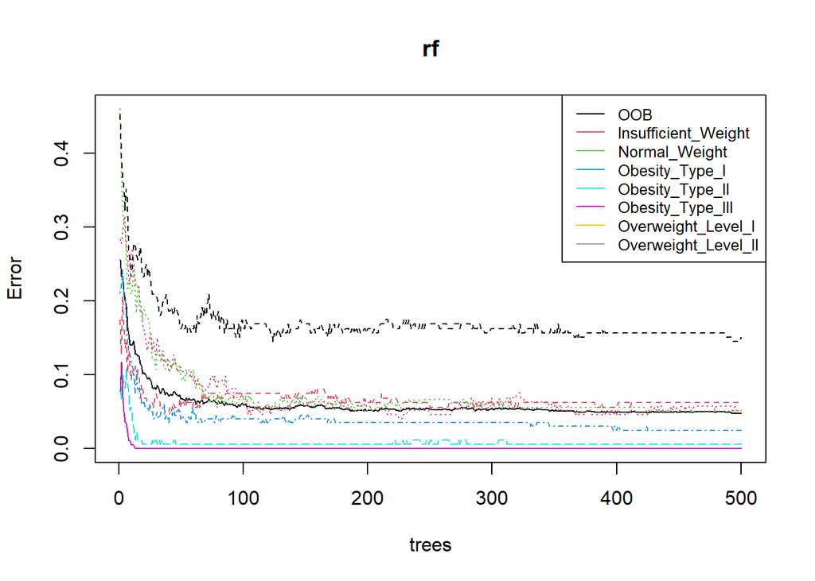

```r
rf <- randomForest(as.factor(NObeyesdad)~., data=train, importance=TRUE,proximity=TRUE)
plot (rf)
legend("topright",
       legend = colnames(rf$err.rate),
       col = 1:ncol(rf$err.rate),
       lty = 1,
       cex = 0.8)
```

Vamos a ver paso a paso el gráfico que nos devuelve la funcion randomForest.

Nos demuestra el error frente al número de arboles durante la creación de los árboles desde 0 hasta 500. Cada linea discontinua representa cada valor (Insufficient_Weight, Normal_Weight, etc) y, la línea continua en negro representa el error medio.

```r
# Calcula la clase (tipo) de cada variable
train_classes <- sapply(df.train, class)
test_classes  <- sapply(df.test,  class)

# Junta en un data.frame para ver las diferencias
class_comparison <- data.frame(
  variable = names(train_classes),
  train    = unname(train_classes),
  test     = unname(test_classes),
  stringsAsFactors = FALSE
)

# Solo para las variables que deberían ser factores
factor_vars <- c("Gender","family_history_with_overweight","FAVC","MTRANS",
                 "CAEC","SMOKE","SCC","NObeyesdad")

na_counts <- sapply(df.test, function(x) sum(is.na(x)))

# Seleccionar columnas
df.train <- train %>%
  dplyr::select(Gender, Height, Weight, family_history_with_overweight, FAVC, FAF, MTRANS, NObeyesdad, Age, FCVC, NCP, CAEC, SMOKE, CH2O, SCC, TUE, CALC)

df.test <- test %>%
  dplyr::select(Gender, Height, Weight, family_history_with_overweight, FAVC, FAF, MTRANS, NObeyesdad, Age, FCVC, NCP, CAEC, SMOKE, CH2O, SCC, TUE, CALC)

# Asegura clases idénticas
for(v in names(df.train)) {
  cls <- class(df.train[[v]])
  if (cls == "factor") {
    # refactoriza usando exactamente los mismos niveles
    df.test[[v]] <- factor(
      as.character(df.test[[v]]),
      levels = levels(df.train[[v]])
    )
  } else if (cls == "numeric") {
    df.test[[v]] <- as.numeric(df.test[[v]])
  } else if (cls == "integer") {
    df.test[[v]] <- as.integer(df.test[[v]])
  } else if (cls == "character") {
    df.test[[v]] <- as.character(df.test[[v]])
  } else if (cls == "logical") {
    df.test[[v]] <- as.logical(df.test[[v]])
  }
}

# Predecir y mostrar matriz de confusión
prediction.rf <- predict(rf, df.test)
cf <- confusionMatrix(prediction.rf, df.test$NObeyesdad)
print(cf)
```

```
## Confusion Matrix and Statistics
##
##                      Reference
## Prediction            Insufficient_Weight Normal_Weight Obesity_Type_I
##   Insufficient_Weight                  56             0              0
##   Normal_Weight                         6            42              2
##   Obesity_Type_I                        0             0             82
##   Obesity_Type_II                       0             0              0
##   Obesity_Type_III                      0             0              0
##   Overweight_Level_I                    0             2              1
##   Overweight_Level_II                   0             0              0
##                      Reference
## Prediction            Obesity_Type_II Obesity_Type_III Overweight_Level_I
##   Insufficient_Weight               0                0                  0
##   Normal_Weight                     0                0                  5
##   Obesity_Type_I                    0                0                  0
##   Obesity_Type_II                  55                0                  0
##   Obesity_Type_III                  0               68                  0
##   Overweight_Level_I                0                0                 51
##   Overweight_Level_II               0                0                  2
##                      Reference
## Prediction            Overweight_Level_II
##   Insufficient_Weight                   0
##   Normal_Weight                         3
##   Obesity_Type_I                        1
##   Obesity_Type_II                       0
##   Obesity_Type_III                      0
##   Overweight_Level_I                    0
##   Overweight_Level_II                  46
##
## Overall Statistics
##
##                Accuracy : 0.9479
##                  95% CI : (0.9221, 0.967)
##     No Information Rate : 0.2014
##     P-Value [Acc > NIR] : < 2.2e-16
##
##                   Kappa : 0.9389
##
##  Mcnemar's Test P-Value : NA
```

[output cut: 24 more lines]

```
## Pos Pred Value                        1.0000                    0.9444
## Neg Pred Value                        1.0000                    0.9810
## Prevalence                            0.1611                    0.1374
## Detection Rate                        0.1611                    0.1209
## Detection Prevalence                  0.1611                    0.1280
## Balanced Accuracy                     1.0000                    0.9355
##                      Class: Overweight_Level_II
## Sensitivity                              0.9200
## Specificity                              0.9946
## Pos Pred Value                           0.9583
## Neg Pred Value                           0.9893
## Prevalence                               0.1185
## Detection Rate                           0.1090
## Detection Prevalence                     0.1137
## Balanced Accuracy                        0.9573
```

Vamos a ver la matriz de confusión.

Vamos a visualizar ahora las variables que tienen más importancia dentro de nuestro modelo

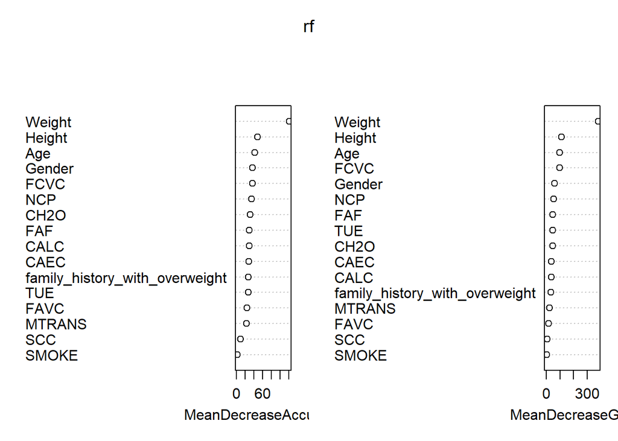

```r
varImpPlot(rf)
```

Parece ser que la más importante es Weigth, la variable de peso del individuo que supera a simple vista todas las variables. Y detrás le siguen Height, la altura y Age, la edad

Esto es llamativo ya que en muchos de los modelos anteriormente usados concueran en que para predecir, la variable con más peso en la mayoría de los modelos es Weigth, principalmente.

Medidas de rendimiento utilizadas:

La matriz de confusión, Accuracy, coeficiente Kappa

En conjunto, estas métricas garantizan que nuestro modelo de Random Forest no solo sea preciso, sino también equilibrado y fiable.

### Naive Bayes

A continuación, vamos a aplicar el método Naive Bayes que estima la clase de obesidad mas probable para cada observación asumiendo independencia entre las variables.

Además, aplicamos Laplace Smoothing (laplace = 1), para evitar que algunas combinaciones de valores tengan probabilidad 0 y así no anulemos la probabilidad total de una clase.

```r
train$NObeyesdad <- as.factor(train$NObeyesdad)
test$NObeyesdad <- as.factor(test$NObeyesdad)

naive_model <- naive_bayes(NObeyesdad ~ ., data = train, usekernel = TRUE, laplace = 1)
pred_classes <- predict(naive_model, newdata = test)
# Matriz de confusión
confusionMatrix(pred_classes, test$NObeyesdad)
```

```
## Confusion Matrix and Statistics
##
##                      Reference
## Prediction            Insufficient_Weight Normal_Weight Obesity_Type_I
##   Insufficient_Weight                  53             2              0
##   Normal_Weight                         7            32              2
##   Obesity_Type_I                        0             0             56
##   Obesity_Type_II                       0             0             17
##   Obesity_Type_III                      0             0              0
##   Overweight_Level_I                    2             4              2
##   Overweight_Level_II                   0             6              8
##                      Reference
## Prediction            Obesity_Type_II Obesity_Type_III Overweight_Level_I
##   Insufficient_Weight               0                0                  0
##   Normal_Weight                     0                0                  8
##   Obesity_Type_I                   11                0                  7
##   Obesity_Type_II                  43                0                  0
##   Obesity_Type_III                  0               68                  0
##   Overweight_Level_I                0                0                 31
##   Overweight_Level_II               1                0                 12
##                      Reference
## Prediction            Overweight_Level_II
##   Insufficient_Weight                   0
##   Normal_Weight                         7
##   Obesity_Type_I                       11
##   Obesity_Type_II                       1
##   Obesity_Type_III                      0
##   Overweight_Level_I                    3
##   Overweight_Level_II                  28
##
## Overall Statistics
##
##                Accuracy : 0.737
##                  95% CI : (0.6922, 0.7784)
##     No Information Rate : 0.2014
##     P-Value [Acc > NIR] : < 2.2e-16
##
##                   Kappa : 0.6915
##
##  Mcnemar's Test P-Value : NA
```

[output cut: 24 more lines]

```
## Pos Pred Value                        1.0000                   0.73810
## Neg Pred Value                        1.0000                   0.92895
## Prevalence                            0.1611                   0.13744
## Detection Rate                        0.1611                   0.07346
## Detection Prevalence                  0.1611                   0.09953
## Balanced Accuracy                     1.0000                   0.75213
##                      Class: Overweight_Level_II
## Sensitivity                             0.56000
## Specificity                             0.92742
## Pos Pred Value                          0.50909
## Neg Pred Value                          0.94005
## Prevalence                              0.11848
## Detection Rate                          0.06635
## Detection Prevalence                    0.13033
## Balanced Accuracy                       0.74371
```

A continuación, hemos implementado manualmente el algoritmo Naive Bayes y asi comprender su funcionamiento interno. Este modelo programado nos sirve como base conceptual pero para la predicción debemos usar el de la función de R. Ya que el rendimiento ha sido muy bajo, porque no incluye optimizaciones, control de errores o transformación de variables que si incluye la función de R:

```r
# Predicciones en TEST
modelo_naive_manual <- entrenar_naive_bayes(train, "NObeyesdad")
pred_test_manual <- sapply(1:nrow(test), function(i) {
  predecir_naive_bayes(modelo_naive_manual, test[i, ])
})

# Evaluación
confusion_test <- confusionMatrix(factor(pred_test_manual, levels = levels(test$NObeyesdad)),
                                  test$NObeyesdad)
print(confusion_test)
```

```
## Confusion Matrix and Statistics
##
##                      Reference
## Prediction            Insufficient_Weight Normal_Weight Obesity_Type_I
##   Insufficient_Weight                   0             0              0
##   Normal_Weight                        62            44             85
##   Obesity_Type_I                        0             0              0
##   Obesity_Type_II                       0             0              0
##   Obesity_Type_III                      0             0              0
##   Overweight_Level_I                    0             0              0
##   Overweight_Level_II                   0             0              0
##                      Reference
## Prediction            Obesity_Type_II Obesity_Type_III Overweight_Level_I
##   Insufficient_Weight               0                0                  0
##   Normal_Weight                    55               68                 58
##   Obesity_Type_I                    0                0                  0
##   Obesity_Type_II                   0                0                  0
##   Obesity_Type_III                  0                0                  0
##   Overweight_Level_I                0                0                  0
##   Overweight_Level_II               0                0                  0
##                      Reference
## Prediction            Overweight_Level_II
##   Insufficient_Weight                   0
##   Normal_Weight                        49
##   Obesity_Type_I                        0
##   Obesity_Type_II                       0
##   Obesity_Type_III                      0
##   Overweight_Level_I                    0
##   Overweight_Level_II                   1
##
## Overall Statistics
##
##                Accuracy : 0.1066
##                  95% CI : (0.0789, 0.1401)
##     No Information Rate : 0.2014
##     P-Value [Acc > NIR] : 1
##
##                   Kappa : 0.0026
##
##  Mcnemar's Test P-Value : NA
```

[output cut: 24 more lines]

```
## Pos Pred Value                           NaN                       NaN
## Neg Pred Value                        0.8389                    0.8626
## Prevalence                            0.1611                    0.1374
## Detection Rate                        0.0000                    0.0000
## Detection Prevalence                  0.0000                    0.0000
## Balanced Accuracy                     0.5000                    0.5000
##                      Class: Overweight_Level_II
## Sensitivity                             0.02000
## Specificity                             1.00000
## Pos Pred Value                          1.00000
## Neg Pred Value                          0.88361
## Prevalence                              0.11848
## Detection Rate                          0.00237
## Detection Prevalence                    0.00237
## Balanced Accuracy                       0.51000
```

# 3. Comparación de Modelos

En este bloque vamos a determinar cuál de todos es el más adecuado, en cuantro a métricas, para predecir el nivel de obesidad de forma más precisa.

Para abordar el problema de clasificación del nivel de obesidad, hemos seleccionado tres familias de métodos que cubren, desde nuestro punto de vista, desde la sencillez y transparencia hasta la capacidad predictiva más avanzada.

Estos 3 modelos, que son los que mejores resultados en cuanto a rendimiento principalmente, son: k-Nearest Neighbors, Bagging y Random Forest. Cada uno basado en similitud, en ensamblado puro y en ensamblado con selección de variables.

Hemos escogido estos tres enfoques porque, en conjunto, cubren muy bien el compromiso entre sencillez, interpretabilidad y potencia predictiva

Vamos a empezar explicando en profundidad cada modelo.

## k-nn

### Por qué lo elegimos

- Es un método “no paramétrico” que no asume ninguna distribución de los datos.
- Clasifica según las observaciones más cercanas en el espacio de características, por lo que es fácilmente interpretable

### Ventajas

- Transparencia: fácil de entender y de implementar.
- Flexibilidad: maneja directamente problemas multiclase sin modificaciones.
- Poco ajuste de hiperparámetros: solo requiere elegir k (el número de vecinos).

### Desventajas

- Sensibilidad a la escala: requiere normalizar o estandarizar previamente.
- Coste computacional: crece con el tamaño del conjunto de entrenamiento.
- Propenso a sobreajuste si k es muy pequeño

## Bagging

### Por qué lo elegimos

- Permite visualizar el efecto de cada árbol a través de predicciones OOB (out-of-bag).

### Ventajas

- Reducción de varianza: disminuye el sobreajuste
- Fácil de implementar sin librerías especializadas.
- Visibilidad OOB: se evalúa el rendimiento usando sólo los datos que no entraron en cada muestra.

### Desventajas

- No reduce correlación entre árboles: todos se entrenan con todas las variables, por lo que pueden ser muy similares.

## Random Forest

### Por qué lo elegimos

- Mejora al bagging añadiendo selección aleatoria de variables en cada división.
- Combina reducción de varianza con menor correlación entre árboles.

### Ventajas

- Muy buena generalización sin excesivo ajuste de hiperparámetros.
- Estimación OOB incorporada para validación interna.
- Importancia de variables: detecta automáticamente qué características aportan más.

### Desventajas

- Menos interpretable que un árbol único o k-NN muy simple.
- Coste computacional superior al de un solo árbol, aunque paralelo.

## Rendimientos de los modelos

[output not shown]

Vamos a comentar la tabla.

En conclusión, Random Forest es el más equilibrado y potente, Bagging se queda unos puntos atrás y k-NN a pesar de ser el más rápido e iterpretable, sufre de sensibilidad.

Es por eso que el modelo más potente y del cual obtenemos un rendimiento y una capacidad predictiva casi perfecta es el Random Forest.

# 4. Conclusiones y trabajo a futuro.

## Análisis en el conjunto de validación del modelo Random Forest

Ahora que ya hemos elegido el modelo que mejor se ajusta a nuestros datos de obesidad, vamos a evaluarlo en el conjunto validacion

```r
# Nos aseguramos de que validacion tenga las mismas columnas y tipos que train (excepto la clase)
for (col in names(train)) {
  if (col %in% names(val)) {
    if (is.factor(train[[col]])) {
      val[[col]] <- factor(val[[col]], levels = levels(train[[col]]))
    } else if (is.numeric(train[[col]])) {
      val[[col]] <- as.numeric(val[[col]])
    }
  }
}

# Predecimos
pred_rf <- predict(rf, newdata = val)
library(caret)

# Nos aseguramos de que val tenga los mismos niveles para la variable respuesta
val$NObeyesdad <- factor(val$NObeyesdad, levels = levels(train$NObeyesdad))

# predicciones
pred_rf <- predict(rf, newdata = val)

# Evaluar con matriz de confusión
conf_rf <- confusionMatrix(pred_rf, val$NObeyesdad)

# Mostrar resultados
print(conf_rf)
```

```
## Confusion Matrix and Statistics
##
##                      Reference
## Prediction            Insufficient_Weight Normal_Weight Obesity_Type_I
##   Insufficient_Weight                  47             0              0
##   Normal_Weight                         2            47              1
##   Obesity_Type_I                        0             0             65
##   Obesity_Type_II                       0             0              1
##   Obesity_Type_III                      0             0              0
##   Overweight_Level_I                    0             0              0
##   Overweight_Level_II                   0             0              0
##                      Reference
## Prediction            Obesity_Type_II Obesity_Type_III Overweight_Level_I
##   Insufficient_Weight               0                0                  0
##   Normal_Weight                     0                0                  2
##   Obesity_Type_I                    1                0                  0
##   Obesity_Type_II                  63                1                  0
##   Obesity_Type_III                  1               67                  0
##   Overweight_Level_I                0                0                 56
##   Overweight_Level_II               0                0                  2
##                      Reference
## Prediction            Overweight_Level_II
##   Insufficient_Weight                   0
##   Normal_Weight                         5
##   Obesity_Type_I                        1
##   Obesity_Type_II                       0
##   Obesity_Type_III                      0
##   Overweight_Level_I                    2
##   Overweight_Level_II                  59
##
## Overall Statistics
##
##                Accuracy : 0.9551
##                  95% CI : (0.9307, 0.9727)
##     No Information Rate : 0.1608
##     P-Value [Acc > NIR] : < 2.2e-16
##
##                   Kappa : 0.9475
##
##  Mcnemar's Test P-Value : NA
```

[output cut: 24 more lines]

```
## Pos Pred Value                        0.9853                    0.9655
## Neg Pred Value                        0.9972                    0.9890
## Prevalence                            0.1608                    0.1418
## Detection Rate                        0.1584                    0.1324
## Detection Prevalence                  0.1608                    0.1371
## Balanced Accuracy                     0.9912                    0.9639
##                      Class: Overweight_Level_II
## Sensitivity                              0.8806
## Specificity                              0.9944
## Pos Pred Value                           0.9672
## Neg Pred Value                           0.9779
## Prevalence                               0.1584
## Detection Rate                           0.1395
## Detection Prevalence                     0.1442
## Balanced Accuracy                        0.9375
```

Evaluando el modelo en validación este alcanza un rendimiento excelente con unos valores de accuracy y Kappa que superan incluso los resultados obtenido en test.

```
Accuracy : 0.9551
```

```
Kappa : 0.9475
```

La sensibilidad media es muy alta también, con un valor de 0,95, lo cual indica que el modelo identifica bien la mayoría de los casos en todas las clases. La especificidad también destaca con un 99,4%, mostrando que el modelo casi no comete falsos positivos.

Comparado con los resultados en test, donde Random Forest ya era el más exacto, al evaluar en validación se ha reafirmado su fiabilidad. Es claramente el más consistente frente a otros modelos, por lo que demuestra ser el modelo con el mejor rendimiento.

Además, ofrece interpretabilidad mediante la importancia de variables, donde destacan el peso, la altura y la edad, lo que refuerza por tanto la coherencia del modelo sobre que estas variables son cruciales para clasificar los niveles de obesidad.

## Conclusiones y propuestas de mejoras

Tras analizar y modelar el conjunto de datos de obesidad, aplicar diversas técnicas, abordar distintos modelos y evaluar su rendimiento con distintas métricas, hemos podido sacar conclusiones sobre ellos.

En definitiva, tras aplicar todos estos modelos, técnicas y compararlas, destacando Random Forest que nos permite obtener las predicciones más precisas y generalizables, los resultados obtenidos han sido útiles y nos han permitido sacar conclusiones acerca de la obesidad que podrían aplicarse en entornos reales.

Algunas mejoras que podríamos añadir sería, si se pudiese, ampliar el número de variables (añadir horas de sueño, trabajo, etc) que podría sernos de bastante utilidad para así hacer un estudio más en profundidad, poder captar aún mejor la complejidad de la obesidad

## Trabajo a Futuro

Desarrollar modelos que incorporen series temporales de peso y hábitos ((por ejemplo, mediante Redes Neuronales) para predecir trayectorias de riesgo de obesidad a lo largo del tiempo.

Implementación de un prototipo de herramienta web o aplicación móvil que permita la carga de datos por parte de profesionales sanitarios y ofrezca predicciones y recomendaciones inmediatas a los usuarios.

Establecer un proceso de reentrenamiento a medida que se recolecten nuevos datos, para mantener la precisión y adaptabilidad de los modelos a cambios en la población o en los hábitos de vida y así que nuestro modelo pueda no acabar obsoleto y siga recibiendo estas actualizaciones de datos de pacientes y usuarios para mejorar el modelo y que siga siendo útil para la sociedad.

Colaboración con profesionales sanitarios (médicos, nutricionistas o dietistas) y así poder incorporar su feedback para ajustar las características (por ejemplo, nuevos indicadores clínicos) y validar que las predicciones sean útiles y realistas en la práctica. Con esto también podríamos organizar sesiones de revisión periódicas para asegurar que el modelo evolucione acorde a los avances médicos y las necesidades de los pacientes consiguiendo de esta forma un mayor impacto real.